# CURSO DE EXTENSÃO “R PARA SAÚDE”

INFORMÁTICA APLICADA À PESQUISA CIENTÍFICA [TURMA: PJ350-2025]

Ryan Almeida, Maria Soares, Carla Cavalcante

10 janeiro, 2026

```r
# Aviso: Essas notas de aula são exclusivas para uso como guia do curso, porém não substituem as referências e materiais de apoio. Quaisquer erros são de responsabilidade dos autores.
# Esse material é protegido por ser propriedade intelectual.
# Logo, ao reproduzir, divulgar ou distribuir notifique as autorias.

# Caso encontre erros, contate os autores imediatamente. Via e-mail ryallmeida@gmail.com
```

```r
# CODADO ORIGINALMENTE EM R, V. 4.5.2
```

# 1 Sobre o curso e os autores

Apostilas dos códigos utilizados nas aulas “Curso: R para Saúde” realizado em parceria entre o Departamento de Ciência Política e o Programa de Pós-graduação em Nutrição da Universidade Federal de Pernambuco. Curso ministrado pelos docentes: [Prof.ª Dr.ª Maria Soares](http://lattes.cnpq.br/6914758127566065) e o [Prof. Dalson Britto](http://lattes.cnpq.br/6683806605359913) e monitorado por [Ryan Almeida](https://github.com/ryallmeida) e [Carla Cavalcante](https://github.com/Carla-Cavalcante)

## 1.1 Maria Soares

## 1.2 Ryan Almeida

## 1.3 Carla Cavalcante

## 1.4 Dalson Britto

# 2 Fundamentos em R

## 2.1 Por que programar? Por que codar exatamente em R?

Motivos para você escolher a Linguagem R

- Linguagem com desenvolvimento comunitário. Logo, constatemente ela se reinventa e se adapta as possibilidades que ou a vida academica ou o mercado pedem.
- Linguagem de programação aberta, então qualquer pessoa pode baixá-la e começar a codar imediatamente e de graça. Diferentemente de outros Softwares pagos comos SPPS ou STATA.
- Mercado de trabalho tem deteminado algumas hardskills que você deve saber e grandes empresas estão cada vez mais interessados em profissionais que saibam usar R.

Bizu da madrinha: presta atenção nesses atalhos que você certamente vai usar quando tiver codando

| Atalho | Funcao |
| --- | --- |
| CTRL + ENTER | Executa a(s) linha(s) selecionada(s) no script |
| ALT + - | Insere o operador de atribuição (<-) |
| CTRL + SHIFT + M | Insere o operador pipe (%>%) |
| CTRL + 1 | Move o cursor para o script |
| CTRL + 2 | Move o cursor para o console |
| CTRL + ALT + I | Cria um chunk em um documento R Markdown |
| CTRL + SHIFT + K | Compila (renderiza) um arquivo R Markdown |
| ALT + SHIFT + K | Abre a janela com todos os atalhos disponíveis |

# 3 Aplicações com dados simulados

## 3.1 Boxplots com estatísticas

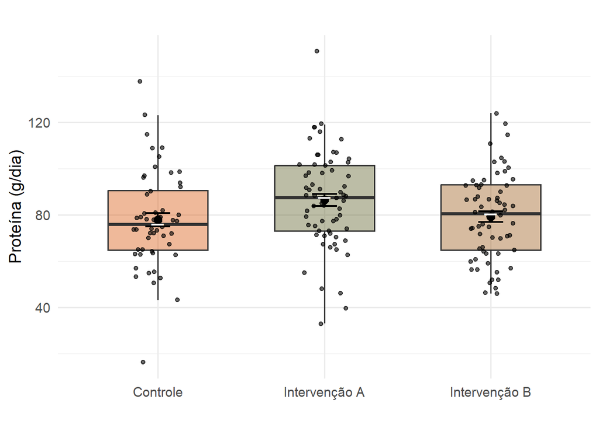

## 3.2 Gráfico de Violino

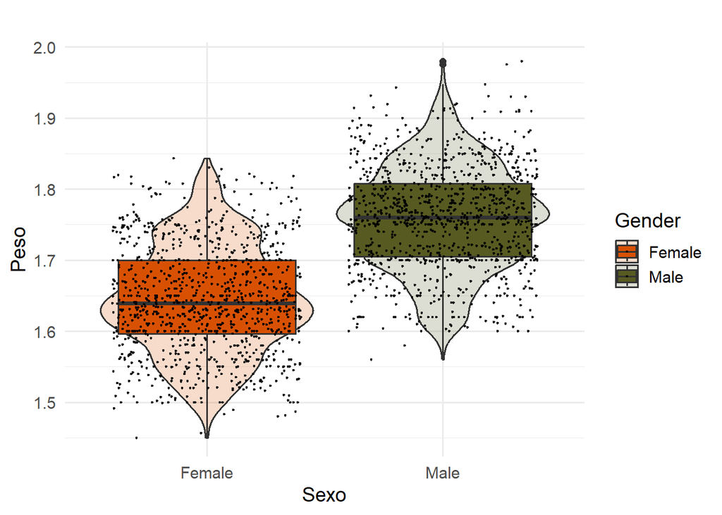

## 3.3 Gráfico de Densidade

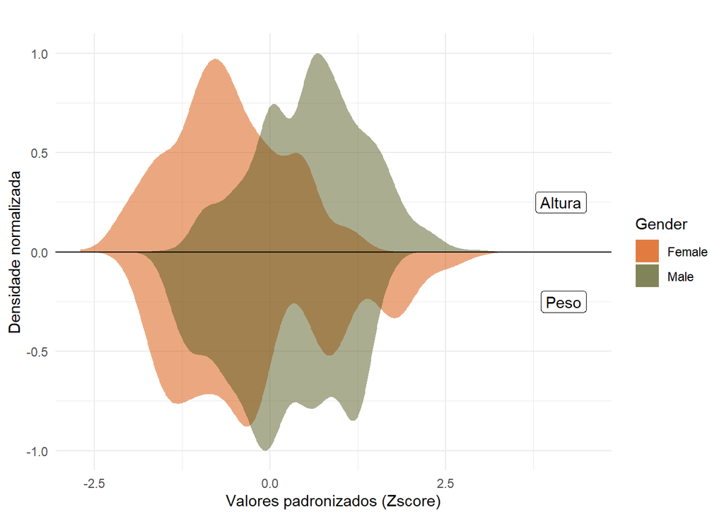

**Figura:** Gráfico de densidade normalizada agrupado por sexo espelhado sob duas variáveis  
**Elaboração própria.** Pires, Soares & Cavalvante (2025).

## 3.4 Ajuste linear por grupo

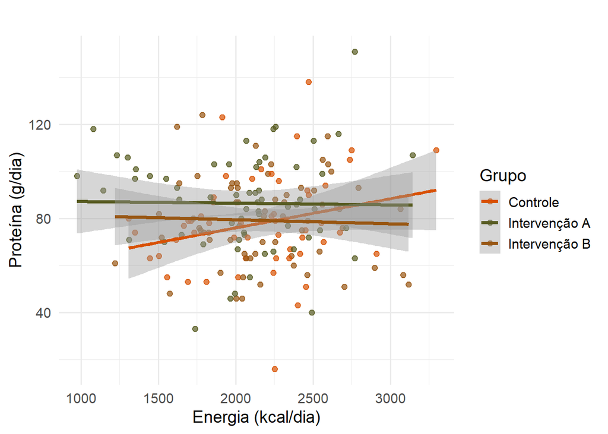

Esses são uns dos muitos pontenciais do R. Se te convencemos a gostar dessa liguagem, continua lendo essa apostila.

# 4 Programação orientada à objetos

A linguagem R, assim como outras existentes tem como possibilidade a criação de objetos. Vejamos alguns exemplos simples

```r
valor <- 10.5678
conjunto <- c(1, 3, 5, 7)
cores <- c("azul", "vermelho")
```

Em cada exemplo, usamos o símbolo de atribuição (“<-”). No R, também é possível usar ‘=’ com a mesma função, mas não aconselhamos porque as vezes pode confundir quem está começando.

No primeiro exemplo, temos um objeto do tipo numérico. No segundo e terceiro temos um vetor, pois concatena informações.

É possível acessar os objetos criados no R. Basta usar o comando `ls()`. E para removê-los caso precise desocupar slots de memória, use:

```r
# COLOQUE A OBJETO QUE VOCÊ QUER REMOVER DENTRO DO PARENTESES DA rm()

rm(); gc()
```

Detalhe importante: o R é uma linguagem q-sensitiva, ou seja, “cores’ é diferente de”Cores” (palavra com letra minúscula vs palavra com letra maiúscula).

Outro detalhe importante: comente seus códigos com #, converse consigo mesmo, pense no seu “eu do futuro” lendo um código escrito por você no passado. Somos muito incopetentes quando começamos algo novo, você pode cometer erros ao codar, e principalmente quando está balisando estatística e ciência de dados com programação. Sempre tente descrever brevemente o que está fazendo na linha de seu script.

Álém disso, também é possível acessar os objetos usando a função print() Note como funciona:

```r
print(valor)
```

```
## [1] 10.5678
```

```r
# OU

valor
```

```
## [1] 10.5678
```

```r
# OU

print(valor, digits = 2)
```

```
## [1] 11
```

## 4.1 Tipos de variáveis em R

| Tipo | Descricao |
| --- | --- |
| Numéricas (numeric) | Números inteiros ou reais, como idade, renda, número de filhos. |
| Datas (Date) | São um tipo especial de variável numérica. |
| Categóricas (factor) | Variáveis qualitativas para as quais não é possível atribuir um valor numérico, como sexo, religião, estado civil ou opinião. |
| Categóricas ordenáveis (ordered) | Variáveis categóricas cujas categorias podem ser hierarquizadas, como grau de escolaridade ou respostas ordenadas. |
| Texto (character) | Características puramente individuais que não podem ser utilizadas para categorizar os indivíduos, usadas em análises qualitativas. |
| Booleanas (logical) | Variáveis cujos valores podem ser VERDADEIRO ou FALSO; no R, TRUE ou FALSE. |

Veja algumas situações-problemas, que talvez te ajudem a dar luz no seu cerébro caso não tenha entendido ainda. Imagine que você coletou dados de 5 pessoas e, para cada uma, tem as seguintes variáveis:

| Variavel | Descricao |
| --- | --- |
| idade | é o número propriamente dito |
| data de uma entrevista | data |
| sexo | categórica (Femino, Masculino, Outro; Você tem três categorias aqui) |
| escolaridade | categórica ordenável (Porque você nâo vira doutor sem antes ter se formado no ABC) |
| relato de opinião | texto de um relato, por exemplo, o R vai entender como um character |
| fumante | booleana, ou fuma ou não fuma, ou TRUE ou FALSE, ou SIM ou NÃO, note que só existe duas possibilidades e nada mais, essa é a essência de uma variável booleana |

## 4.2 Operadores Lógico e Matemáticos

| operador | significado | tipo |
| --- | --- | --- |
| + | Soma | Aritmético |
| - | Subtração | Aritmético |
| / | Divisão | Aritmético |
| * | Multiplicação | Aritmético |
| ^ | Exponenciação | Aritmético |
| > | Maior que | Relacional |
| < | Menor que | Relacional |
| >= | Maior ou igual a | Relacional |
| <= | Menor ou igual a | Relacional |
| == | Igual a | Relacional |

### 4.2.1 Atividade: “Use o R como calculadora”

```r
# DIGITE E VEJA O OUTPUT

2 + 2
4/2
2 - 1
4*2
```

```r
# DIGITE E VEJA O OUTPUT
# LEMBRE QUE O RESULTADO DE UM TESTE LÓGICO É SEMPRE UM OUTPUT BOOLEANO

3 > 2
5 < 2
(6 > 5) & (7 > 8)
(6 > 5) | (7 > 8)
```

## 4.3 Vetores, tabelas, matrizes e listas

Em computação, é bastante comum lidar com conjuntos de valores, como notas, preços, nomes ou qualquer outro tipo de informação organizada. Para tornar essa manipulação possível de forma eficiente, utilizam-se estruturas de dados, que permitem armazenar e acessar múltiplos valores de maneira sistemática. Quando se trabalha com dados de um mesmo tipo, como números inteiros, valores reais ou cadeias de caracteres, uma das estruturas mais fundamentais é o vetor.

Os vetores podem ser compreendidos como **agregados homogêneos unidimensionais**, isto é, estruturas que reúnem vários valores do mesmo tipo em uma única variável, organizados em uma única dimensão. Essa característica faz dos vetores a base para praticamente todas as demais estruturas de dados no R, funcionando como o elemento mais simples de organização da informação.

As tabelas conhecidas no R como `data.frame` são estruturas particularmente importantes para a análise de dados. Uma tabela é composta por múltiplos vetores de mesmo comprimento, sendo que cada vetor representa uma variável. Diferentemente das matrizes, esses vetores podem ser de tipos distintos, como numéricos, lógicos ou caracteres. Essa flexibilidade torna as tabelas semelhantes a planilhas ou bases de dados, sendo ideais para representar dados experimentais ou observacionais. No R, a criação de tabelas é realizada por meio da função `data.frame()`, consolidando-as como a estrutura central para organização e análise de dados empíricos.

As matrizes, por sua vez, podem ser entendidas como uma extensão dos vetores, pois mantêm a homogeneidade de tipo, mas permitem a organização dos dados em mais de uma dimensão. Diferentemente dos vetores unidimensionais, as matrizes possibilitam o acesso aos dados por meio de múltiplos índices, como linhas e colunas. Conceitualmente, uma matriz pode ser pensada como um vetor cujos elementos são, eles próprios, vetores, organizados de forma recursiva. Esse tipo de estrutura é especialmente útil em situações em que é necessário correlacionar informações, como em cálculos matemáticos ou análises estatísticas.

Já as listas representam uma estrutura mais flexível. Uma lista é um objeto formado por uma coleção ordenada de componentes, nos quais cada elemento pode ser de um tipo diferente. Em uma mesma lista, é possível reunir vetores, valores lógicos, matrizes, arrays e até outras listas. No R, listas são criadas por meio da função `list()`. O acesso aos seus elementos pode ser feito tanto pelos operadores de colchetes (`[]`), que indicam a posição do elemento desejado, quanto pelo operador cifrão (`$`), que permite acessar componentes nomeados. Esses operadores não se limitam às listas, sendo amplamente utilizados também em matrizes, arrays e tabelas.

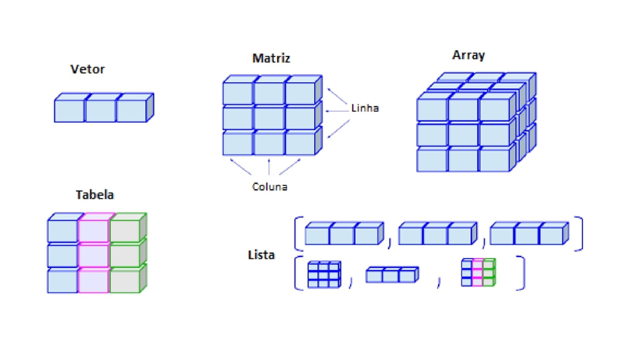

O R é uma linguagem que possui em sua versão inicial diversos pacotes que possuem alguns tipos de funções. No entanto, existem muitas outras funções que podem ser obtidas através de pacotes que podem ser instalados.

```r
# PARA INSTALAR UM NOVO PACOTE, USE A FUNÇÃO
install.packages("nome do pacote")

# CARREGUE O PACOTE USANDO
library(nome do pacote) # OU
require(nome do pacote)
```

# 5 Introdução à Estatística Descritiva

O R nasce na área da estatística. O potencial do R está justamente em unir o Data Science com toda a teoria da estatística e realizar todos os calculos complexos adjacentes à ela. Então, não podemos ser omissos e deixar de revisar o básico da área.

## 5.1 Mas para que serve a estatística afinal?

Deste modo, podemos definir Estatística como sendo a ciência que se preocupa com a coleta, organização, apresentação, análise e interpretação de dados. Didaticamente, podemos dividir a estatística em duas partes: **a estatística descritiva e a inferência estatística.**

A estatística descritiva se refere à maneira de apresentar um conjunto de dados em tabelas e gráficos, e ao modo de resumir as informações contidas nestes dados a algumas medidas.

Já a inferência estatística baseia-se na teoria das probabilidades para estabelecer conclusões sobre todo um grupo (chamado população), quando se observou apenas uma parte (amostra) desta população.

A esse ponto, como você já deve saber, as característica de uma população ou amostra são denominadas variáveis. (Em caso de dúvidas, visite a sessão anterior para revisar esses conceitos)

## 5.2 Medidas de Posição

As principais medidas de posição são composta pelos “três Ms” da estatística, e certamente você ja ouviu falar deles na escola. Que são a média, mediana e a moda, também conhecidas como pedidas de tendência central (conceito sinônimo ao titulo da subssesão). Essas resumem um conjunto de dados em um único valor central que representa a “localização” ou o “ponto de equilíbrio” dos dados, podendo ser eles os quartis e percentis outros tipos de medidas de posição (tambem chamados de medidas separatrizes)

### 5.2.1 Média Aritimetica

Considere uma amostra composta por $n$ observações numéricas $x_1, x_2, x_3, \dots, x_n$. A primeira medida descritiva fundamental é a média aritmética, que representa o valor central obtido ao distribuir igualmente a soma total dos dados entre todas as observações. Algebricamente, inicia-se somando todos os valores da amostra, o que pode ser representado pela soma $\sum_{i=1}^{n} x_i$. Em seguida, essa soma é dividida pelo número total de observações $ n$, resultando na média amostral, expressa por $\bar{x} = \frac{1}{n}\sum_{i=1}^{n}x_i$. Do ponto de vista algébrico, a média pode ser interpretada como o valor constante que, se substituísse todas as observações individuais, preservaria exatamente a mesma soma total dos dados.

Em geral, utiliza-se $\bar{x}$ para denotar a média amostral e $\mu$ para denotar a média populacional.

No R, a média de uma amostra é obtida por meio da função `mean()`. A média é uma medida de posição que é muito afetada por **outliers**. Outliers são observações que não correspondem aos valores esperados de uma população ou amostra. Em geral, são valores que estão muito acima ou muito abaixo da maioria dos valores observados.

Mas, quais são os critérios que se utilizam para definir se uma observação é um outlier ou não? No entanto, a resposta é: Depende. A palavra final é sempre do pesquisador que conhece o fenômeno, e pode informar se a informação obtida é realmente aceitável ou não. Assim, de todo modo tanto na estatística descritiva quanto na inferencial é de suma importância entender “quem”” é essa observação fora da curva e ver o quanto ela muda o resultado de descrições e de modelos estatísticos. Guarde no seu coração essa essa pergunta: como flutuaria as medidas de posição com outlier e sem outlier? A resposta dessa pergunta determina os resultados da sua pesquisa.

Se você ainda não entendeu o que é outlier talvez essa metafora ajude: “Se uma pessoa estiver com os pés dentro de um forno com temperatura de 50 graus Celsius e a cabeça dentro de um freezer com temperatura de zero graus na média estará uma temperatura agradável?” Isso faz sentido pra você? Pois é, isso é um outlier.

Então, se isso é um problema tão grande, como confiar em pesquisas que usam unicamente da média para demonstrar o comportamento dos dados? Por esse motivo é importante que uma medida de posição sempre esteja acompanhada de uma medida de dispersão.

### 5.2.2 Mediana

A **mediana**, por sua vez, não depende da soma dos valores, mas da posição relativa de cada observação no conjunto de dados. Para calculá-la, é necessário ordenar a amostra em ordem crescente, obtendo-se a sequência $x_{(1)} \le x_{(2)} \le \dots \le x_{(n)}$. Se o número de observações for ímpar, isto é, $n = 2k + 1$, a mediana será o elemento que ocupa a posição central da sequência ordenada, dada por $x_{(k+1)}$. Caso o número de observações seja par, isto é, $n = 2k$, não há um único valor central; nesse caso, a mediana é definida como a média aritmética dos dois valores centrais, sendo calculada como $\frac{x_{(k)} + x_{(k+1)}}{2}$. Algebricamente, a mediana pode ser entendida como o ponto que divide a distribuição ordenada em duas partes com o mesmo número de observações, independentemente da magnitude dos valores extremos.

### 5.2.3 Moda

A **moda** é a medida de tendência central mais simples do ponto de vista algébrico, pois não envolve operações aritméticas como soma ou divisão, mas sim a contagem de frequências (guarda essa informação no coração). Seja $f(x_i)$ a frequência absoluta associada ao valor $x_i$. A moda é definida como o valor da variável que maximiza essa frequência, podendo ser representada simbolicamente por:

$$\text{Moda} = \arg\ max_{x_i} f(x_i)$$

Em termos algébricos, o procedimento consiste em identificar qual valor aparece o maior número de vezes no conjunto de dados. Dependendo da distribuição das frequências, o conjunto pode ser unimodal, bimodal, multimodal ou mesmo amodal, quando não existe um valor com frequência superior às demais.

De todo modo, dá uma olhadinha nesse quadro de fichamento de fim de sessão:

| Indicador_Adequado | Objetivo_da_Analise |
| --- | --- |
| Média | Avaliar impacto total, média geral ou tendência global |
| Mediana | Avaliar situação típica, comportamento comum, ou dados enviesados |
| Mediana | Evitar distorções causadas por outliers |
| Comparar Média e Mediana | Descrever heterogeneidade |

No R, tem uma forma excelente de pedir todas essas informações via um comando nativo, ou como também chamam, via R base.

```r
# DIGITE

x <- c(1, 5, 10, 15, 20, 25, 30, 35)
base::summary(x)
```

```
##    Min. 1st Qu.  Median    Mean 3rd Qu.    Max.
##    1.00    8.75   17.50   17.62   26.25   35.00
```

```r
# OS OUTPUTS DO R SEMPRE SAIRÃO EM INGLÊS, ENTÃO NÃO SE ASSUSTE
```

### 5.2.4 Quartis

Quartis podem ser compreendidos como “medidas que dividem os dados ordenados em quatro partes iguais: primeiro quartil (Q1), segundo quartil (Q2) e terceiro quartil (Q3).”

Pode-se dizer que 25% dos valores estão abaixo de Q1 e 75% dos valores estão acima de Q1. O segundo quartil é exatamente igual à mediana e aritmeticamente falando a diferença entr Q3 e Q1 é chamada de amplitude interquartílica.

### 5.2.5 Percentis

O k-ésimo percentil, denotado por Pk,é o valor na posição, de forma que k% das medidas são menores que a posição Pk, ou seja, (100-k)% das observações são maiores que Pk. O k-ésimo percentil é determinado por: Pk = é o valor do kn/100 − ésimo termo no conjunto de dados ordenados, onde k é o percentil e n é o tamanho da amostra. Para além dessa definição formal, a gente pode compreender percentil como a divisão em 100 partes iguais do banco de dados. E o percentil é a determinada unidade que você observa ou que está balisando em sua análise. O percentil serve para você entender um comportamento de uma proporção específica de seus dados. Por exemplo, o código abaixo tenta responder a seguinte hipotese: qual é o valor abaixo do qual se encontram 0,1% das observações válidas da variável x?

```r
# DIGITE

quantile(x, probs = 0.001, type = 4, na.rm = T)
```

Em resumo, essa função é utilizada para localizar um ponto muito baixo da distribuição dos dados (como outliers, por exemplo) ignorando valores ausentes e usando um método específico de definição de quantil. Ela é particularmente útil em análises exploratórias, diagnósticos de assimetria, estudo de caudas da distribuição e decisões metodológicas relacionadas à exclusão ou tratamento de valores extremos. Se você estiver se perguntando, porque em termos percentuais o argumento probs está escrito errado, mas não se preocupe, o cálculo desse argumento baseia-se em probabilidade não em proporção propriamente dita.

## 5.3 Medidas de Dispersão

### 5.3.1 Amplitude

> “Amplitude é a medida mais simples de dispersão e definida como sendo a diferença entre o maior e o menor valor entre os dados observados.”

A amplitude é bastante influenciada por outliers. Por isso, não é uma boa medida para dados que contenham outliers. Ainda, essa é uma medida de dispersão que utiliza somente 2 observações, independente do tamanho da amostra.

### 5.3.2 Variância e Desvio padrão

A variância leva em consideração os valores extremos e os valores intermediários, isto é, expressa melhor os resultados obtidos. A variância relaciona os desvios em torno da média, ou, mais especificamente, é a média aritmética dos quadrados dos desvios. Sendo a variância calculada a partir dos quadrados dos desvios, ela é um número em unidade quadrada em relação à variável em questão, o que, sob o ponto de vista prático, é um inconveniente; por isso, tem pouca utilidade na estatística descritiva, mas é extremamente importante na inferência estatística e em combinações de amostras.

No cálculo da variância, os valores obtidos a partir da diferença entre cada observação e a média podem ser chamados de **resíduos** ou **desvios**. Esses resíduos possuem uma propriedade fundamental: quando somados diretamente, o resultado é obrigatoriamente zero. Isso ocorre porque a média aritmética é justamente o ponto de equilíbrio da distribuição. Diante disso, surge uma questão: se a soma simples dos desvios é sempre nula, ela não pode ser utilizada para medir a dispersão dos dados.

A solução encontrada pela Estatística está na álgebra dos quadrados. Ao elevar os resíduos ao quadrado, elimina-se o cancelamento entre valores positivos e negativos, permitindo que todas as diferenças contribuam para a medida de variabilidade. Assim, trabalha-se com a **soma dos quadrados dos resíduos**, que será sempre um número positivo.

No entanto, esse valor bruto (a soma dos quadrados dos resíduos) não pode ser interpretado isoladamente. Ele não possui significado substantivo direto, pois seu tamanho depende fortemente do tamanho da amostra: quanto maior o número de observações, maior tende a ser essa soma, ainda que a dispersão relativa dos dados permaneça a mesma. Por isso, é necessário padronizar esse valor por meio de uma média dos quadrados dos desvios, o que nos conduz ao conceito de variância.

Nesse ponto, é essencial distinguir entre variância amostral e variância populacional. A variância populacional considera todos os elementos da população e divide a soma dos quadrados dos desvios pelo número total de observações. Já a variância amostral introduz um ajuste algébrico, dividindo essa soma por $n - 1$, de modo a corrigir o viés decorrente do uso de uma amostra para estimar a variabilidade da população.

O **desvio padrão amostral** mede o grau de dispersão dos dados em torno da média e envolve uma sequência de operações algébricas bem definidas. O primeiro passo é calcular a média amostral $\bar{x}$. Em seguida, calcula-se, para cada observação, o desvio em relação à média, dado por $x_i - \bar{x}$. Esses desvios são então elevados ao quadrado, resultando em $(x_i - \bar{x})^2$, o que evita o cancelamento algébrico dos desvios positivos e negativos, já que a soma dos desvios simples em relação à média é sempre igual a zero. O passo seguinte consiste em somar todos os desvios quadráticos, obtendo-se $\sum_{i=1}^{n} (x_i - \bar{x})^2$. Essa soma é então dividida por $n - 1$, e não por $n$, como forma de corrigir o viés decorrente do fato de a média ter sido estimada a partir da própria amostra, o que implica a perda de um grau de liberdade.

Esse quociente define a variância amostral, $s^2=\frac{1}{n-1}\sum_{i=1}^{n}(x_i - \bar{x})^2$. Por fim, toma-se a raiz quadrada da variância para retornar à mesma unidade de medida dos dados originais, obtendo-se o desvio padrão amostral, expresso por $s = \sqrt{\frac{1}{n-1}\sum_{i=1}^{n} (x_i - \bar{x})^2}$. Dessa forma, o desvio padrão sintetiza, de maneira algébrica e conceitual, o quão afastados os valores da amostra estão, em média, da média aritmética.

Por fim, o desvio padrão fornece uma medida de dispersão das observações ao redor da média. Um desvio padrão pequeno indica que os dados possuem uma amplitude pequena ao redor da média. Já, um desvio padrão grande, indica que os dados possuem uma amplitude grande ao redor da média.

### 5.3.3 Assimetria

Denomina-se assimetria o grau de afastamento de uma distribuição em relação à simetria perfeita. Quando representamos uma distribuição por meio de um histograma ou de um polígono de frequência, estamos, na prática, observando a forma com que os dados se organizam em torno de um valor central.

Em uma distribuição simétrica, o lado esquerdo e o lado direito da curva são espelhos um do outro. Isso implica algo muito forte: a média é igual a mediana e igual a moda (mas não se assuste que na prática é rarissimo isso acontecer). Ou seja, todas as noções de centralidade coincidem.

Porque analisar essa assimetria (ou simetria raramente) importa? Porque muitas técnicas estatísticas assumem simetria (especialmente a normalidade em alguns modelos da estatísitica inferencial); porque a média deixa de ser representativa quando a distribuição é muito assimétrica; porque políticas públicas, análises sociais e indicadores podem ser distorcidos por poucos valores extremos; porque a assimetria revela tendÊncias e padrões, como concentração ou distorção estrutural nos dados.

Em termos simples: a assimetria nos diz se a “a maioria das observações vive perto do centro” ou se “poucos puxam tudo para um lado”.

Desde cedo, os estatísticos perceberam que duas distribuições podem ter a mesma média e, ainda assim, apresentarem comportamentos completamente distintos quando observadas graficamente por meio de um histograma ou de um polígono de frequências (como demonstra o gráfico abaixo). Essa diferença não está na posição central, mas na forma da curva, isto é, no modo como os valores se afastam para a esquerda ou para a direita. É exatamente esse afastamento que se convencionou chamar de assimetria.

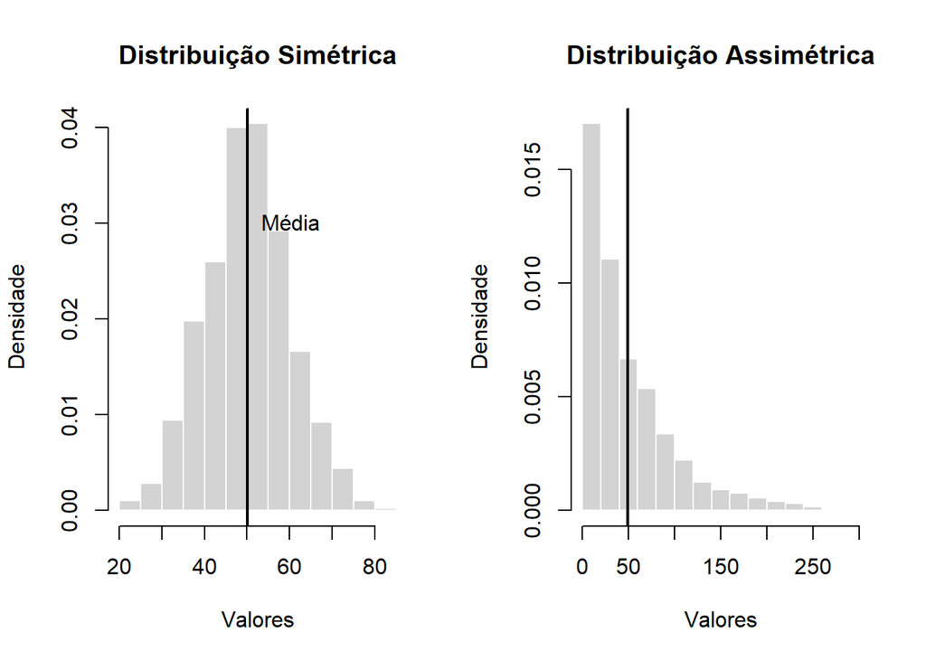

[output not shown]

[output not shown]

Na prática, a maioria das distribuições observadas em dados sociais, econômicos ou de saúde apresenta algum grau de deformação, sendo, portanto, assimétrica.

Foi nesse contexto que Karl Pearson buscou uma forma de quantificar a assimetria, transformando uma percepção visual em uma medida numérica objetiva. A ideia central de Pearson era simples e engenhosa: se, em distribuições simétricas, média, mediana e moda coincidem, então o afastamento entre essas medidas poderia ser utilizado como um indicador do grau e da direção da assimetria.

A primeira abordagem de Pearson parte da comparação entre a média e a moda. Ele observa que, em distribuições assimétricas à direita, a cauda longa empurra a média para valores maiores, enquanto a moda permanece próxima ao pico da distribuição. Já nas distribuições assimétricas à esquerda, ocorre o movimento oposto: a média é puxada para valores menores. Assim, a diferença entre a média e a moda,carrega informação direta sobre a direção da assimetria. No entanto, Pearson reconhece rapidamente uma limitação: essa diferença depende da escala dos dados. Um mesmo formato de distribuição pode gerar valores muito distintos apenas por mudança de unidade de medida. Para resolver esse problema, Pearson recorre a uma estratégia clássica da Estatística: a padronização. Ao dividir a diferença entre média e moda pelo desvio padrão $s$, ele obtém uma medida adimensional, comparável entre diferentes conjuntos de dados. Dessa forma, surge o chamado Primeiro Coeficiente de Assimetria de Pearson, definido como

$$AS_1 = \frac{\bar{x} - Mo}{s}$$

Esse coeficiente não apenas indica a presença de assimetria, mas também sua direção: valores positivos indicam assimetria à direita, enquanto valores negativos indicam assimetria à esquerda.

Apesar de conceitualmente elegante, o primeiro coeficiente enfrenta uma dificuldade prática importante: a moda nem sempre é facilmente identificável, especialmente em distribuições contínuas ou em amostras pequenas. Diante disso, Pearson propõe uma alternativa baseada na mediana, uma medida sempre bem definida e menos sensível a valores extremos.

A solução se apoia em uma relação empírica amplamente observada em distribuições moderadamente assimétricas, segundo a qual a moda pode ser aproximada por

$$Mo \approx 3Md - 2\bar{x}$$

Ao substituir essa aproximação na expressão original do coeficiente, a diferença entre média e moda transforma-se em

$$\bar{x} - Mo
= \bar{x} - (3Md - 2\bar{x})
= \bar{x} - 3Md + 2\bar{x}
= 3\bar{x} - 3Md
= 3(\bar{x} - Md)$$

Novamente, para eliminar o efeito da escala, Pearson divide essa expressão pelo desvio padrão, obtendo o Segundo Coeficiente de Assimetria de Pearson:

$$AS_2 = \frac{3(\bar{x} - Md)}{s}$$

Esse segundo coeficiente se torna particularmente popular por sua facilidade de aplicação e por dispensar o cálculo da moda.

A interpretação dos coeficientes de Pearson é direta e intuitiva. Quando o coeficiente de assimetria é igual a zero, conclui-se que a distribuição é simétrica. Valores positivos indicam assimetria positiva, ou seja, uma cauda mais longa à direita da distribuição, situação em que se observa a relação (Moda < Mediana < Média). Por outro lado, valores negativos indicam assimetria negativa, caracterizada por uma cauda mais longa à esquerda, com a ordenação (Média < Mediana < Moda)

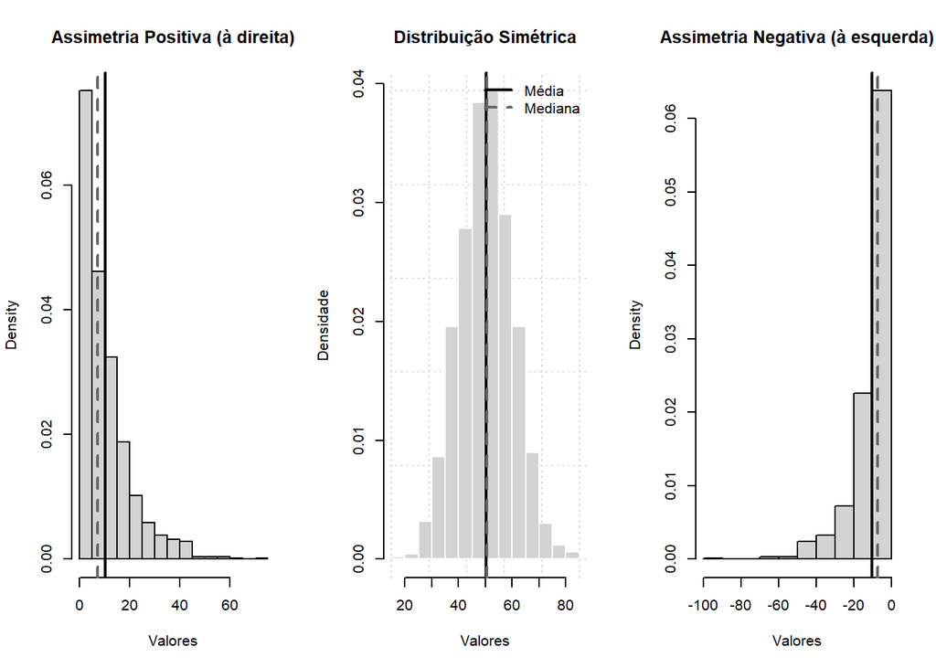

### 5.3.4 Curtose

A curtose é uma medida descritiva que indica como a massa de probabilidade de uma distribuição se organiza em torno do centro quando comparada a uma distribuição de referência, tradicionalmente a curva normal. Mais do que “pico alto ou baixo”, a curtose informa como os dados se concentram no centro e nas caudas, permitindo avaliar se a distribuição é mais aberta, mais achatada ou mais concentrada do que o padrão normal. Analisar a curtose é importante porque distribuições com médias e desvios padrão idênticos podem apresentar comportamentos substantivamente distintos quanto à ocorrência de valores extremos, o que tem implicações diretas para inferência estatística

#### 5.3.4.1 Classificações da curtose

```
##       75%
## 0.2638057
```

```
##       75%
## 0.3135446
```

```
##       75%
## 0.2311607
```

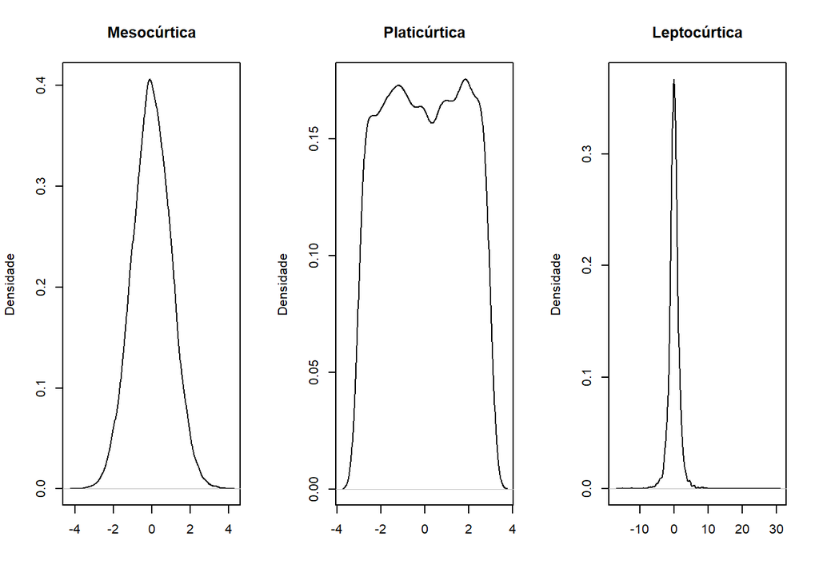

#### 5.3.4.2 Demonstração algébrica

Uma forma particularmente robusta de medir a curtose é por meio de quantis, o que reduz a sensibilidade da medida a outliers extremos. Considere uma amostra de tamanho $n$, ordenada de forma crescente como

$$x_{(1)} \le x_{(2)} \le \cdots \le x_{(n)}$$

A partir dessa ordenação, definem-se os quartis e percentis que servirão de base para o coeficiente de curtose. O primeiro quartil, denotado por Q1, corresponde ao percentil 25 da distribuição, enquanto o terceiro quartil, Q3, corresponde ao percentil 75.

A diferença entre o terceiro quartil e o primeiro quartil, mede a amplitude interquartílica, que representa a dispersão dos dados na região central da distribuição.

De forma complementar, consideram-se os percentis mais afastados do centro: o percentil 10, e o percentil 90. A diferença entre o percentil 90 e o percentil 10 expressa a dispersão associada às caudas da distribuição, isto é, aos valores relativamente extremos, mas ainda estáveis do ponto de vista estatístico. O coeficiente de curtose baseado em quantis é então definido pela razão entre a dispersão central e a dispersão das caudas, devidamente normalizada, sendo expresso por

$$K = \frac{Q_3 - Q_1}{2\,(P_{90} - P_{10})}$$

Algebricamente, essa razão compara quanto os dados se espalham no centro em relação ao quanto se espalham nos extremos. O fator 2 no denominador atua como um ajuste de escala que permite a comparação direta com a distribuição normal.

A partir desse coeficiente, estabelece-se uma classificação objetiva das distribuições quanto ao seu grau de curtose. Quando o valor de $K$ é aproximadamente igual a 0,263, diz-se que a distribuição é mesocúrtica, isto é, apresenta um equilíbrio entre concentração central e caudas semelhante ao da curva normal. Quando 𝐾 > 0,263, a dispersão central é relativamente maior do que a dispersão nas caudas, caracterizando uma distribuição platicúrtica, mais achatada e aberta do que a normal. Por outro lado, quando 𝐾 < 0,263, a dispersão central é relativamente menor do que a dispersão nas caudas, indicando uma distribuição leptocúrtica, mais afilada no centro e com maior peso relativo nas caudas.

#### 5.3.4.3 Comparação dos comportamento

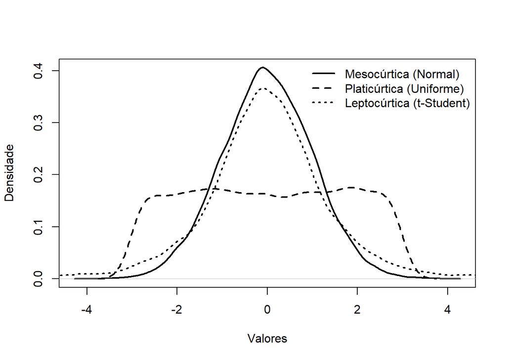

# 6 Um summary mais pontente

Lembra de quando usamos a função summary do R base? Pois é, tem formas mais robustas de pedir informações mais completas. Dá uma olhada no comando que segue.

```r
# DIGITE

if(!require("psych")) {
  install.packages("psych")
}

x <- c(1, 5, 10, 15, 20, 25, 30, 35)
psych::describe(x)
```

```
##    vars n  mean    sd median trimmed   mad min max range skew kurtosis   se
## X1    1 8 17.62 12.05   17.5   17.62 14.83   1  35    34 0.03    -1.68 4.26
```

```r
# ESSE PACOTE É VOLTADO PARA PESQUISADORES DA PSICOLOGIA REALIZAREM ALGUMAS TÉCNICAS DE  PSICOMETRIA. ENTRETANTO, A FUNÇÃO describe() É MUITO MAIS POTENTE DO QUE FUNÇÕES NATIVAS DO R.

# NOTAS PARA INTERPRETAÇÃO DO OUTPUT
# Vars     POSIÇÃO DA VARIÁVEL
# n        NÚMERO DE OBSERVAÇÕES
# mean     MÉDIA
# sd       DESVIO PADRÃO
# median   MEDIANA
# trimmed  MEDIA APARADA [INTERVALO ENTRE O PERCENTIL 10 E 90]
# mad      DESVIO ABSOLUTO MEDIANO
# min      OBSERVAÇÃO MINIMA
# max      OBSERVAÇÃO MÁXIMA
# range    AMPLITUDE TOTAL
# skew     ASSIMETRIA DA DISTRIBUIÇÃO
# kurtosis CURTOSE EM EXCESSO [CURTOSE - 3]
# se       ERRO PADRÃO
```

# 7 Plottagem em R base

A visualização de dados é uma etapa fundamental e crítica em diversas áreas de análise, como estatística, química, física e biologia.

No contexto da estatística, a visualização é a chave para construir a intuição necessária sobre o conjunto de dados. É a partir dessa intuição visual que o analista pode escolher o teste estatístico ou modelo matemático mais adequado para resolver o problema em questão.

As visualizações podem variar em complexidade, indo desde:

- Medidas Resumo Simples: Como frequência, média, variância, desvio padrão, mínimo, máximo, entre outras.
- Tabelas: Onde um conjunto dessas medidas é organizado de forma estruturada.
- Gráficos: Representações visuais de (uma parte) dos dados, que permitem identificar padrões, outliers e distribuições.

> Segundo o estatístico norte-americano Leland Wil-kinson, “um gráfico é o mapeamento dos dados a partir de atributos estéticos (como posição, cor, forma, tamanho) de objetos geométricos (pontos, linhas, barras, caixas)” (WILKINSON, 2005).

## 7.1 Gráfico de dispersão

No ambiente de programação R, o comando mais simples e básico para criar um gráfico a partir de dois objetos (ou variáveis a depender do contexto) do tipo numérico é o `plot()`.

Este tipo de representação gráfica é popularmente conhecido como gráfico de dispersão (ou `*scatter plot*`). Ele é ideal para visualizar a relação ou a correlação entre duas variáveis quantitativas. Faça o exemplo que segue no seu computador.

```r
# DIGITE

x <- c(1, 5, 10, 15, 20, 25, 30, 35)
y <- c(8, 16, 14, 21, 38, 25, 43, 39)
```

```r
?plot

# ISSO É VOCÊ PERINDO AJUDA PARA ENTENDER A FUNÇÃO. VOCÊ PODE FAZER ISSO SEMPRE QUE NÃO SE LEMBRAR DIREITO DE UM COMANDO.
# A PARTE RUIM É QUE VOCÊ TEM QUE SABER INGLÊS, JÁ A PARTE BOA É QUE VOCê APRENDE INGLÊS NO PROCESSO
```

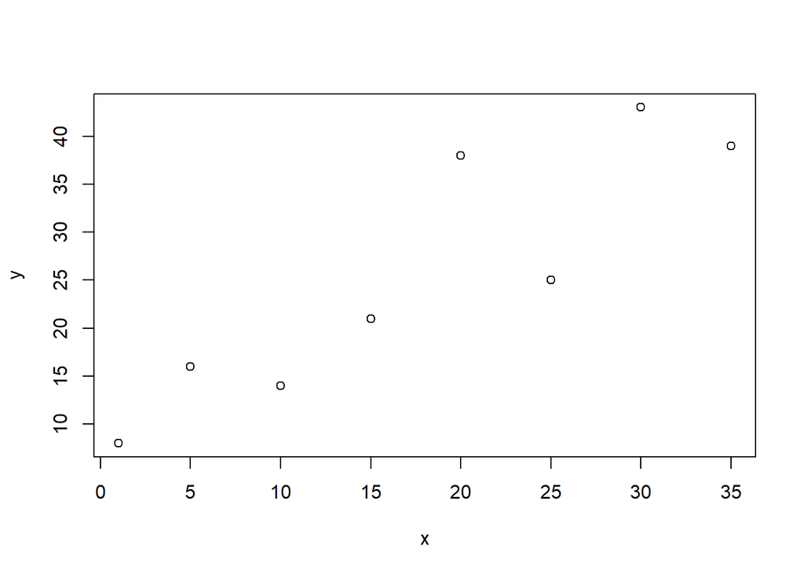

```r
# GRÁFICO DE DISPERSÃO

plot(y ~ x)
```

```r
plot(x, y)

# EM R, EXISTE INÚMERAS FORMAS DE FAZER O MESMO COMANDO. EXEMPLO DISSO É O CÓDIGO ACIMA QUE É EQUIVALENTE A FUNÇÃO SUPRACITADA
```

Conheça a seguir os principais argumentos da função `plot()`, o que a literatura chama de “parâmetros de visualização gráfica”

## 7.2 Parâmetros de visualização da função plot

| parametro | descricao | funcao_visual |
| --- | --- | --- |
| col | Cor dos elementos do gráfico (nome, número ou rgb()) | Estética |
| pch | Tipo de caractere/símbolo dos pontos | Forma |
| type | Tipo de gráfico (pontos, linhas, ambos etc.) | Estrutura |
| cex | Tamanho do caractere ou ponto | Escala visual |
| lty | Tipo de linha | Estilo |
| xlim | Limites do eixo x (horizontal) | Escala do eixo |
| ylim | Limites do eixo y (vertical) | Escala do eixo |
| xlab | Título do eixo x | Rotulagem |
| ylab | Título do eixo y | Rotulagem |
| main | Título principal do gráfico | Narrativa |

Quando abrimos a função `plot()` no R e nos deparamos com argumentos como `col`, `pch`, `cex` ou `xlim`, a sensação inicial é quase sempre a de arbitrariedade: por que esses nomes? por que tão curtos? por que em inglês? A provocação que vale ser feita, no entanto, é outra: **e se esses parâmetros não forem meros atalhos técnicos, mas a materialização de uma gramática técnico-científica específica?**

Comecemos pela cor. `col`, abreviação de *color*, não é um detalhe estético secundário, mas um operador semântico. Ao escolher uma cor, o pesquisador estabelece hierarquias visuais, produz contrastes e direciona o olhar do leitor. A cor, portanto, não adorna o dado; ela o interpreta. O mesmo vale para `pch`, que vem de *plotting character*, um resquício histórico da época em que gráficos eram impressos com caracteres tipográficos. Ainda que hoje pareça anacrônico, o termo revela algo fundamental: cada ponto em um gráfico é um signo, um caractere que representa uma observação (ou amostra, a depender do contexto). Mudar o símbolo é mudar a forma como a observação se apresenta ao usuário/interlocutor.

**Figura:** Signo e código dos plotting character no R

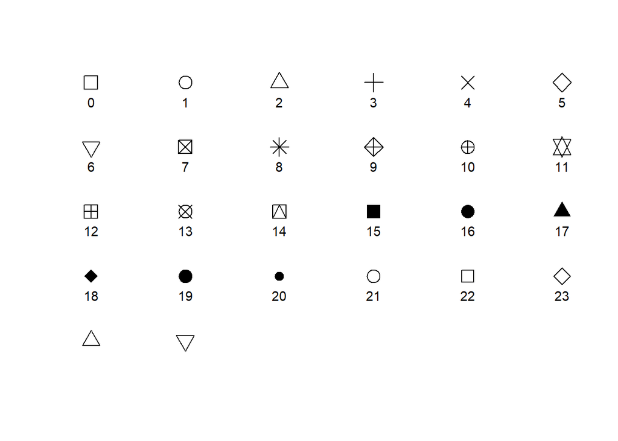

Fonte: **Elaboração própria.** Pires, Soares & Cavalvante (2025).

A escolha do `type` (pontos, linhas ou ambos) explicita ainda mais essa dimensão ontológica da visualização. Pontos sugerem observações discretas; linhas insinuam continuidade, processo, trajetória. Trata-se de uma tomada de posição analítica: **o fenômeno que estou observando é pontual ou processual?** O R obriga o pesquisador a responder a essa pergunta, ainda que de forma implícita.

**Figura:** Signo e código do argumento type no R

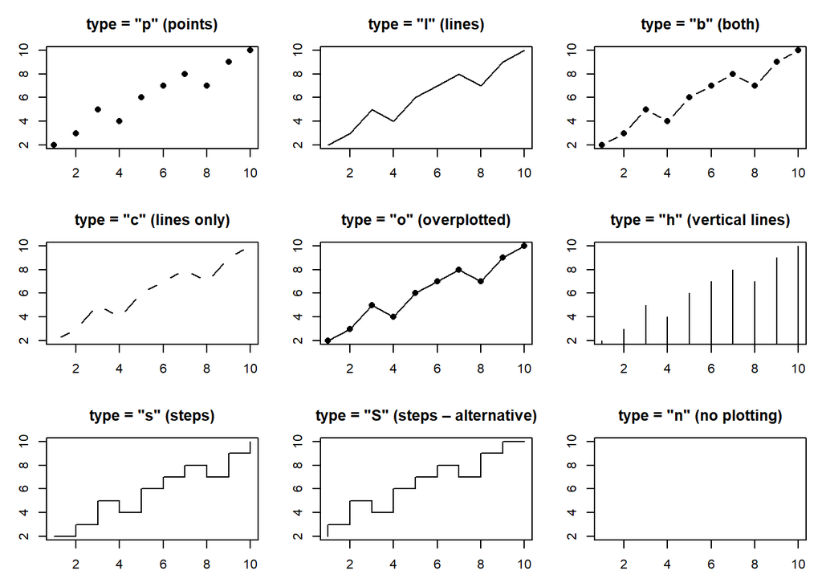

Fonte: **Elaboração própria.** Pires, Soares & Cavalvante (2025).

Outros parâmetros reforçam esse caráter decisório. `cex`, de *character expansion*, controla o tamanho dos símbolos e textos. Varia numa escala continua de zero a um determinado número muito grande, as referências indicam não colocar um valor maior que 3. Assim, ao ampliar ou reduzir um ponto, o pesquisador sinaliza relevância. O mesmo se aplica a `lty`, de *line type*: linhas contínuas, tracejadas ou pontilhadas comunicam distinções, comparações, cenários.

**Figura:** Evidências de flutuações nos parâmetros do argumento cex no R

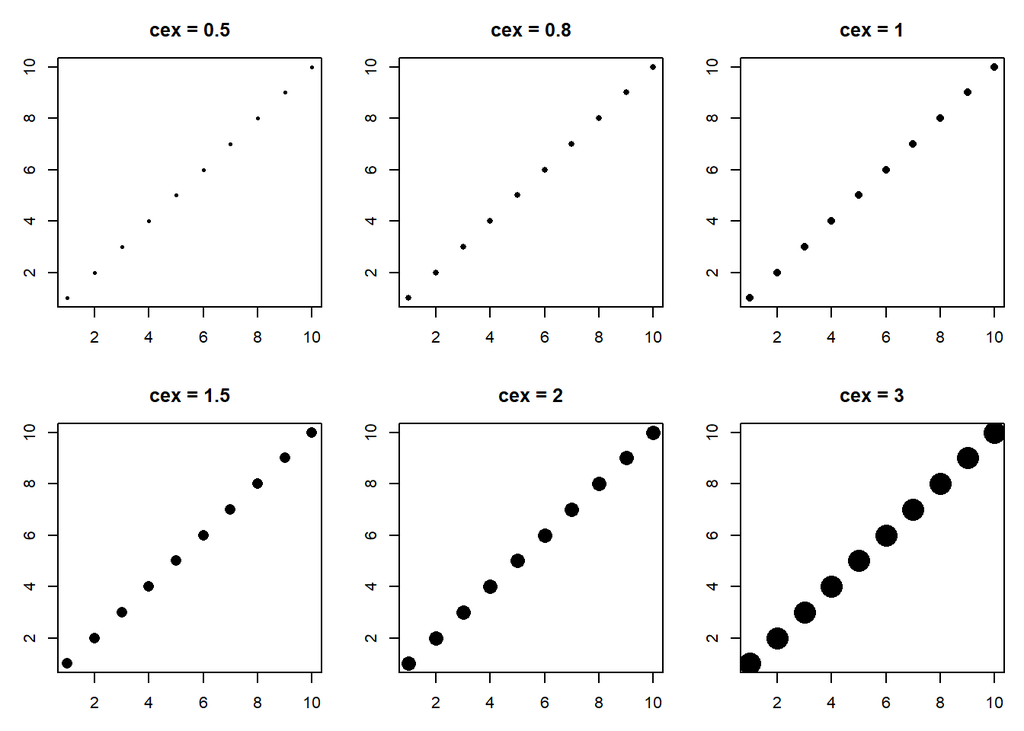

Fonte: **Elaboração própria.** Pires, Soares & Cavalvante (2025).

Talvez onde essa dimensão política da visualização se torne mais evidente seja nos limites dos eixos. `xlim` e `ylim`, abreviações de *x limits* e *y limits*, definem onde a narrativa gráfica começa e termina. Controlar os limites é controlar a escala; controlar a escala é controlar a percepção. Um mesmo conjunto de dados pode parecer estável ou dramático dependendo desses parâmetros. O R, ao exigir que esses limites sejam explicitados quando necessário, expõe um ponto crucial: **não existe gráfico neutro**.

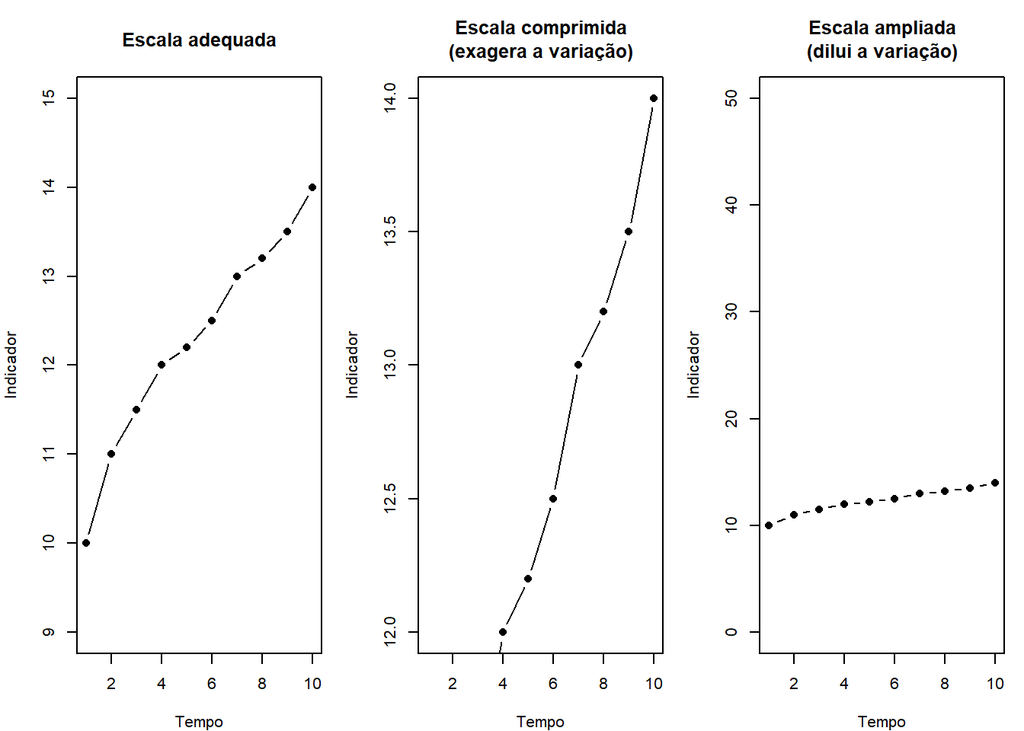

No gráfico acima, o que se faz é um **experimento controlado de visualização**: os dados permanecem rigorosamente os mesmos em todos os gráficos, e a única coisa que varia são os **limites do eixo y**, definidos pelo argumento `ylim`. Isso permite isolar o efeito da escala gráfica sobre a interpretação, mostrando que a mudança de leitura não vem dos números, mas da forma como eles são enquadrados.

No primeiro gráfico, o argumento `ylim = c(9, 15)` define um intervalo vertical ligeiramente maior do que o intervalo real dos dados. O resultado é uma visualização proporcional, em que o crescimento aparece de forma moderada e coerente com os valores observados. Esse gráfico funciona como um ponto de referência: ele mostra o fenômeno sem exageros nem minimizações, permitindo uma leitura equilibrada da tendência.

No segundo gráfico, o `ylim` é comprimido para `c(12, 14)`. Como a variação dos dados ocupa quase todo o espaço vertical disponível, pequenas diferenças entre os valores são amplificadas visualmente. A curva parece íngreme, quase explosiva, mesmo que os incrementos reais sejam modestos. O código, portanto, demonstra como uma simples alteração de escala pode induzir uma interpretação alarmista, sem que nenhum dado tenha sido modificado.

No terceiro gráfico, ocorre o movimento inverso. O `ylim = c(0, 50)` cria um eixo vertical excessivamente amplo em relação aos valores observados. Nesse contexto, a mesma tendência de crescimento praticamente desaparece: a linha parece quase horizontal, sugerindo estabilidade ou insignificância. Mais uma vez, os dados são idênticos; o que muda é apenas a moldura gráfica que os contém.

Por fim, para finalizar essa parte dos parâmetros de visualização os rótulos e o título (`xlab`, `ylab` e `main`) só se usa quando necessário, visto que muitas vezes esses dados são inseridos diretamente nos artigos científicos.

### 7.2.1 Atividade: “Faça seu próprio gráfico”

```r
# DIGITE O QUE SEGUE E TESTE DIFERENTES PARÂMETROS DE VISUALIZAÇÃO GRÁFICA

plot(x, y,
     col = "blue",
     pch = 1,
     type = "p",
     cex = 1.0,
     lty = 1,
     xlim = c(0, 45),
     ylim = c(0, 50),
     xlab = "Variável X",
     ylab = "Variável Y",
     main = "Título que você desejar aqui"
       )
```

## 7.3 Parâmetros de visualização da função legend

A função `legend()` funciona em conjunto com o com a função `plot()`

| parametro | descricao | funcao_visual |
| --- | --- | --- |
| x, y | Posição da legenda no gráfico (ex.: ‘bottomright’, ‘top’, ‘center’, etc.) | Posicionamento |
| legend | Texto exibido na legenda | Rotulagem |
| ncol | Número de colunas da legenda | Estrutura |
| title | Título da legenda | Narrativa |
| horiz | Se TRUE, a legenda é exibida horizontalmente | Orientação |
| col | Cor dos pontos ou linhas na legenda | Estética |
| pch | Tipo de símbolo (ponto) exibido na legenda | Forma |
| lty | Tipo de linha exibida na legenda | Estilo |
| lwd | Espessura da linha exibida na legenda | Escala visual |
| bty | Tipo da caixa ao redor da legenda (‘o’ = com caixa, ‘n’ = sem caixa) | Estrutura |

## 7.4 Mudando a tipo de letra, cor e “grid”

O grid aos que não conhecem é uma grade regular que fica no fundo do gráfico. Auxilia na visualização das coordenadas de um ponto particular. E adicionado ao gráfico pelo argumento panel.first

| parametro | descricao | funcao_visual |
| --- | --- | --- |
| font | Tipo de fonte usada no texto do gráfico (1 = padrão, 2 = negrito, 3 = itálico, 4 = negrito e itálico) | Tipografia |
| font.axis | Tipo de fonte do texto dos eixos | Tipografia |
| font.lab | Tipo de fonte dos nomes (rótulos) dos eixos | Tipografia |
| font.main | Tipo de fonte do título principal | Tipografia |
| col | Cor geral do texto e dos elementos do gráfico | Estética |
| col.axis | Cor do texto dos eixos | Estética |
| col.lab | Cor dos nomes (rótulos) dos eixos | Estética |
| col.main | Cor do texto do título principal | Narrativa |
| col.sub | Cor do texto do subtítulo (se houver) | Narrativa |
| fg | Cor das linhas dos eixos do gráfico | Estrutura |
| panel.first (grid) | Argumento usado para adicionar o grid antes de desenhar os dados | Estrutura |
| nx, ny | Número de células do grid nas direções x e y | Escala espacial |
| col (grid) | Cor das linhas do grid | Estética |
| lty (grid) | Tipo de linha do grid | Estilo |
| lwd (grid) | Espessura das linhas do grid | Escala visual |

### 7.4.1 Atividade: Faça seu próprio gráfico

Tente criar nove gráficos do mesmo conjunto de dados, alterando parâmetros gráficos com par(), para visualizar claramente como os parâmetros de visualização alteram a narrativa dos dados plottados, mesmo sem mudar os dados. Explique, se possível, nove histórias diferentes.

```r
# DIGITE

# Dados de exemplo

x <- 1:10
y <- c(2, 4, 3, 6, 7, 9, 8, 10, 9, 11)

par(mfrow = c(3, 3))  # 3 linhas, 3 colunas

plot(
  x, y,
  type = "b",
  pch = 19,
  col = "darkblue",
  lty = 1,
  lwd = 2,
  cex = 1.3,
  xlim = c(0, 11),
  ylim = c(0, 12),
  main = "Gráfico personalizado",
  xlab = "",
  ylab = "",

  # Tipografia
  font.main = 2,
  font.lab  = 3,
  font.axis = 1,

  # Cores do texto
  col.main = "darkred",
  col.lab  = "darkgreen",
  col.axis = "black",

  # Grid com panel.first
  panel.first = grid(
    nx  = NULL,
    ny  = NULL,
    col = "lightgray",
    lty = "dotted",
    lwd = 1
  )
)

legend(
  x = "bottomright",
  legend = "Legenda",
  col = "darkblue",
  pch = 19,
  lty = 1,
  lwd = 2,
  title = "Legenda",
  horiz = FALSE,
  bty = "n"
)

par(mfrow = c(1, 1))  # 1 linha, 1 colunas
```

## 7.5 Boxplot

Outro gráfico extremamente famoso é o boxplot, ou também conhecido como gráfico de caixas (tradução do termo anterior)

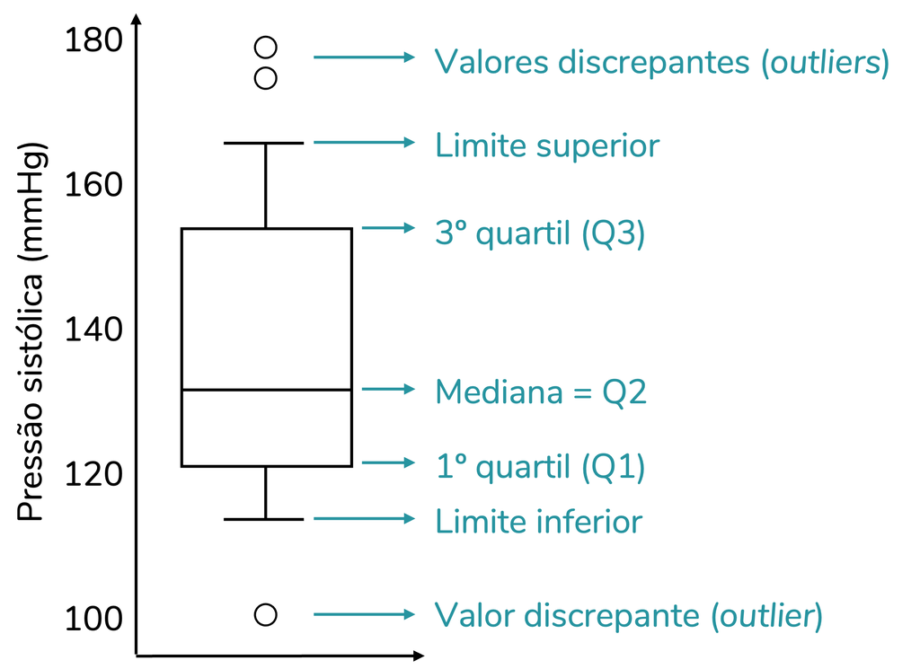

**Figura:** Boxplot representando a distribuição e as estatísticas principais de uma variável  
Fonte: [Fernanda Peres](https://fernandafperes.com.br/)

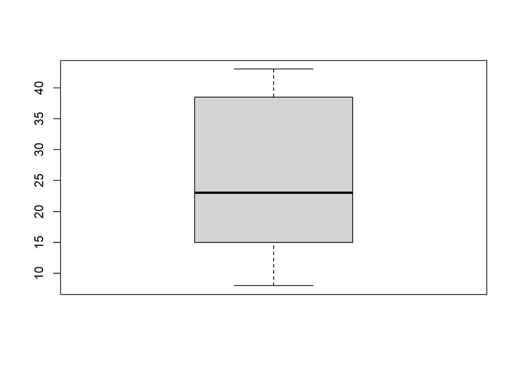

```r
# PARA PLOTAR UM BOXPLOT SEMELHANTE AO ACIMA USE O QUE SEGUE
boxplot(y)
```

## 7.6 Histograma

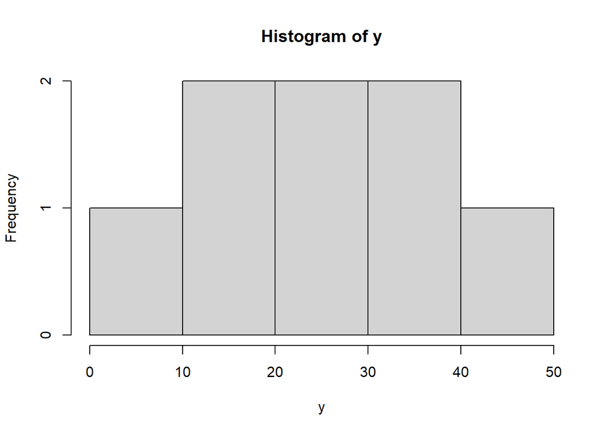

```r
# USE

hist(y)
```

# 8 Conjunto de Dados, testes de hipotese e Introdução à Regressão Linear

## 8.1 Conjunto de Dados

Como usar um data.frame() ?

| Faixa_etaria | IMC_medio | Consumo_frutas | Taxa_obesidade |
| --- | --- | --- | --- |
| 10–19 anos | 221 | 23 | 87 |
| 20–29 anos | 246 | 20 | 142 |
| 30–39 anos | 261 | 19 | 195 |
| 40–49 anos | 273 | 18 | 231 |
| 50–59 anos | 278 | 19 | 250 |
| 60–69 anos | 269 | 21 | 218 |
| 70–79 anos | 258 | 24 | 186 |
| 80+ anos | 249 | 25 | 157 |

Como acessar elementos de um data.frame? Use a estrutura que segue: nome_do__objeto$variavel

```r
# DIGITE

dados_imc$Faixa_etaria
```

```
## [1] "10–19 anos" "20–29 anos" "30–39 anos" "40–49 anos" "50–59 anos"
## [6] "60–69 anos" "70–79 anos" "80+ anos"
```

```r
dados_imc$IMC_medio
```

```
## [1] 221 246 261 273 278 269 258 249
```

```r
dados_imc$Consumo_frutas
```

```
## [1] 23 20 19 18 19 21 24 25
```

```r
dados_imc$Taxa_obesidade
```

```
## [1]  87 142 195 231 250 218 186 157
```

Como remover informações do banco de dados? Suponha que, por algum motivo, não queiramos que a tabela gerada pelo R apresente indivíduos que tenham mais de 80 anos. No exemplo acima, precisamos retirar a oitava linha:

```r
# DIGITE

dados_imc <- dados_imc[-8,]

# BIZU DA MADRINHA: ANTES DA VIRGULA REPRESENTA AS OBSERVAÇÕES E DEPOIS DA LINHA REPRESENTAM AS COLUNAS
```

| Faixa_etaria | IMC_medio | Consumo_frutas | Taxa_obesidade |
| --- | --- | --- | --- |
| 10–19 anos | 221 | 23 | 87 |
| 20–29 anos | 246 | 20 | 142 |
| 30–39 anos | 261 | 19 | 195 |
| 40–49 anos | 273 | 18 | 231 |
| 50–59 anos | 278 | 19 | 250 |
| 60–69 anos | 269 | 21 | 218 |
| 70–79 anos | 258 | 24 | 186 |

## 8.2 Testes de Hipóteses

H0 ⟶ Hipótese que nega a existência de relação entre as variáveis Ha(1) ⟶ Hipótese que se opõe a hipótese nula

Exemplo: Ho ⟶não há mudança significativa devido ao plano alimentar Ha ⟶ o plano alimentar reduz o nível de colesterol LDL.

Mas como comparar essas duas hipóteses? Em qual devemos acreditar? A resposta está no p-value (ou no português, p-valor). Essa medida estatística, determina a probabilidade de se obter um resultado igual ou mais extremo do que aquele observado na amostra, assumindo que a hipótese nula é verdadeira. Quando o p-valor é baixo, a hipótese nula deve ser rejeitada, para um nível de significância estatística de 5%.

| Comparacao_pvalor | Nivel_Significancia | Interpretacao_Resultado | Confianca_Rejeitar_H0 |
| --- | --- | --- | --- |
| p-valor ≤ 0,01 | Altamente significativo | Fortes evidências contra H0 | Muita confiança |
| p-valor ≤ 0,05 | Significativo | Evidências contra H0 | Confiança |
| p-valor ≤ 0,1 | Marginalmente significativo | Algumas evidências contra H0 | Pouca confiança |

| Item | Afirmacao |
| --- | --- |
| 1 | O p-valor não indica a probabilidade de que a hipótese nula seja verdadeira. |
| 2 | O p-valor não indica que os resultados foram produzidos aleatoriamente. |
| 3 | O p-valor não indica o tamanho do efeito observado. |
| 4 | O p-valor não mensura a importância substantiva dos resultados observados. |
| 5 | O p-valor não deve ser interpretado sozinho quando houver outras ferramentas disponíveis. |
| 6 | O p-valor não deve ser interpretado quando os pressupostos de seu cálculo forem violados. |
| 7 | O p-valor não deve ser interpretado quando se trabalha com a população (pois o teste de hipótese é sobre amostras). |

## 8.3 Introdução à Regressão Linear

Um método para modelar o relacionamento entre duas ou mais variáveis e serve para prever a variável resposta (y) com base nos valores das variáveis preditoras (x), a fim de quantificar a força dessa relação. Entretanto, qual é a hipótese da regressão linear?

Um exemplo possível na área da saúde: existe uma associação estatisticamente significativa entre a ingestão diária de sódio (variável preditora) e os níveis de pressão arterial sistólica (variável resposta) em um grupo de pacientes? Objetivo: Determinar se os dados fornecem evidências de que o sódio é um fator a ser considerado no manejo da hipertensão. Se a evidência for fraca, pode-se argumentar que, para aquele grupo, o foco deve estar em outros fatores.

A equação

$$\hat{Y}_i = \hat{\beta}_0 + \sum_{j=1}^{k} \hat{\beta}_j X_{ji} +
\varepsilon_i$$

representa um **modelo de regressão linear múltipla** e descreve como o valor estimado de uma variável dependente é explicado por um conjunto de variáveis independentes.

Em primeiro lugar, $\hat{Y}_i$ indica o valor estimado da variável resposta para o indivíduo (ou observação) $i$. Trata-se do resultado que o modelo prevê com base nas informações disponíveis, e não do valor observado diretamente nos dados. O uso do “chapéu” (^) sinaliza que se trata de uma estimativa produzida pelo modelo estatístico.

O termo $\hat{\beta}_0$ é o intercepto da regressão. Ele representa o valor esperado de $Y$ quando todas as variáveis explicativas $X_{ji}$ assumem valor zero. Em termos substantivos, o intercepto pode ser interpretado como um ponto de referência ou condição basal, ainda que, em muitos contextos empíricos, essa situação (todas as variáveis iguais a zero) não seja realista. Mesmo assim, o intercepto é fundamental para posicionar corretamente a reta (ou hiperplano) de regressão.

O somatório

$$\sum_{j=1}^{k} \hat{\beta}_j X_{ji}$$

expressa a contribuição conjunta das $k$ variáveis independentes para explicar Y. Cada coeficiente $\hat{\beta}_j$ indica o efeito médio associado à variável $X_j$, mantendo todas as demais constantes. Em termos interpretativos, $\hat{\beta}_j$ informa quanto se espera que $\hat{Y}_i$ varie quando $X_{ji}$ aumenta uma unidade, assumindo que as outras variáveis do modelo não se alterem. Assim, os coeficientes capturam relações parciais, e não efeitos brutos ou isolados.

O termo $\varepsilon_i$ representa o erro aleatório ou resíduo associado à observação i. Ele corresponde à parcela de $Y_i$ que não é explicada pelas variáveis incluídas no modelo. Em termos substantivos, o erro agrega fatores não observados, imprecisões de medida e variações aleatórias inevitáveis nos fenômenos sociais e empíricos.

Ao interpretar o resultado de uma regressão linear, o foco recai principalmente sobre os coeficientes $\hat{\beta}_j$, seus sinais (positivos ou negativos), suas magnitudes e sua significância estatística. Um coeficiente positivo indica uma associação direta entre a variável explicativa e a variável dependente; um coeficiente negativo indica uma associação inversa. A significância estatística, por sua vez, informa se o efeito estimado é suficientemente distinto de zero para que não seja atribuído apenas ao acaso, dado um nível de confiança pré-estabelecido.

Além dos coeficientes individuais, a regressão deve ser interpretada de forma global, observando-se medidas de ajuste do modelo, como o $R^2$, que indica a proporção da variância de (Y) explicada pelo conjunto das variáveis independentes. Em conjunto, esses elementos permitem avaliar tanto a força explicativa do modelo quanto a plausibilidade substantiva das relações estimadas.

### 8.3.1 Principais pressupostos da Regressão Linear

Não esqueça: a violação dos pressupostos da regressão pode levar a estimativas enviesadas, erros-padrão incorretos, testes t e f inválidos, e conclusões estatísticas equivocadas.

[output not shown]

### 8.3.2 Será que dieta melhora a saúde?

```r
# VAMOS TESTAR, USE OS DADOS QUE SEGUEM

bd <- read.csv("https://raw.githubusercontent.com/ryallmeida/r_p_saude/refs/heads/main/database/synthetic_health_data.csv")

# DÁ UMA OLHADA NO BANCO DE DADOS
```

[output not shown]

[output cut: 170 more lines]

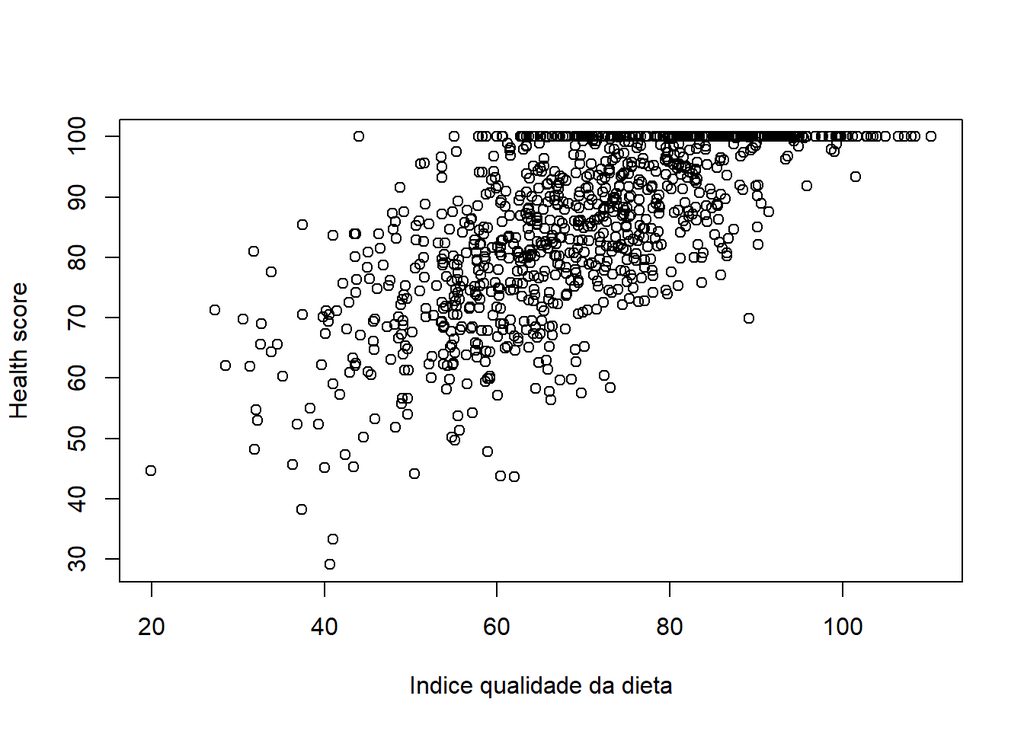

```r
# O MODELO DE REGRESSÃO SEGUE O SEGUINTE COMANDO
modelo <- lm(Health_Score ~ Diet_Quality, data = bd)

# ACESSE OS RESULTADOS DO MODELO DA SEGUINTE FORMA
summary(modelo)
```

```
##
## Call:
## lm(formula = Health_Score ~ Diet_Quality, data = bd)
##
## Residuals:
##     Min      1Q  Median      3Q     Max
## -38.194  -6.067   0.648   6.569  30.622
##
## Coefficients:
##              Estimate Std. Error t value Pr(>|t|)
## (Intercept)  42.11988    1.51059   27.88   <2e-16 ***
## Diet_Quality  0.61985    0.02112   29.35   <2e-16 ***
## ---
## Signif. codes:  0 '***' 0.001 '**' 0.01 '*' 0.05 '.' 0.1 ' ' 1
##
## Residual standard error: 9.993 on 998 degrees of freedom
## Multiple R-squared:  0.4633, Adjusted R-squared:  0.4628
## F-statistic: 861.6 on 1 and 998 DF,  p-value: < 2.2e-16
```

## 8.4 Método dos Mínimos Quadrados Ordinários

O Método dos Mínimos Quadrados Ordinários (MQO) é o fundamento matemático e estatístico que permite transformar um conjunto de dados observados em um modelo linear estimado. A sua importância decorre do fato de que ele fornece um critério claro, operacional e teoricamente justificado para escolher os coeficientes $\beta_0, \beta_1, \ldots, \beta_k$ que melhor descrevem a relação entre as variáveis.

A primeira expressão

$$\min_{\beta_0, \beta_1, \dots, \beta_k}\sum_{i=1}^{n}\left( Y_i -
\beta_0 - \sum_{j=1}^{k} \beta_j X_{ji} \right)^2$$

define o **problema de otimização central do MQO**. O que se busca é encontrar os valores dos parâmetros que minimizam a soma dos quadrados dos resíduos. O termo entre parênteses representa a diferença entre o valor observado (Y_i) e o valor ajustado pelo modelo linear. Ao elevar essa diferença ao quadrado, o método garante que erros positivos e negativos não se anulem e, ao mesmo tempo, penaliza erros grandes de forma mais severa do que erros pequenos. Assim, o MQO escolhe os coeficientes que produzem, no conjunto, o **melhor ajuste médio possível** aos dados.

A importância dessa minimização está no fato de que ela fornece uma **regra objetiva** para estimar os parâmetros. Não se trata de um ajuste visual ou arbitrário, mas de uma solução única (sob condições padrão) derivada de um critério matemático explícito. Em termos geométricos, o MQO projeta o vetor de valores observados (Y) sobre o espaço gerado pelas variáveis explicativas, garantindo que os resíduos sejam ortogonais a esse espaço. Isso confere ao modelo uma propriedade central: não há informação linear adicional nas variáveis explicativas que possa reduzir ainda mais os erros.

A segunda expressão

$$\hat{\varepsilon}_i = Y_i - \hat{\beta}_0 - \sum_{j=1}^{k} \hat{\beta}_j
X_{ji}$$

define o resíduo estimado para cada observação. O resíduo mede exatamente aquilo que o modelo não consegue explicar. A importância desse termo é dupla. Primeiro, ele permite avaliar a qualidade do ajuste, pois resíduos pequenos indicam que o modelo descreve bem os dados, enquanto resíduos grandes sugerem omissões, má especificação ou alta variabilidade não explicada. Segundo, os resíduos são a base para toda a inferência estatística associada à regressão: testes de hipóteses, intervalos de confiança e diagnósticos do modelo dependem diretamente do seu comportamento.

Do ponto de vista teórico, o MQO é especialmente importante porque, sob hipóteses relativamente fracas (linearidade, exogeneidade, variância constante e ausência de multicolinearidade perfeita), os estimadores obtidos possuem propriedades desejáveis. Eles são não viesados, consistentes e, pelo Teorema de Gauss–Markov, apresentam a menor variância possível entre todos os estimadores lineares não viesados. Isso significa que, dentro dessa classe, nenhum outro método produz estimativas mais precisas em média.

Além disso, o MQO cria uma ponte direta entre álgebra, geometria e estatística aplicada. Ele pode ser interpretado como um problema de minimização, como uma projeção em espaços vetoriais ou como um procedimento inferencial probabilístico.

Em síntese, a importância dos Mínimos Quadrados Ordinários reside em três aspectos centrais: ele fornece um critério matemático rigoroso para estimar coeficientes, permite quantificar sistematicamente o erro por meio dos resíduos e garante propriedades estatísticas ótimas sob condições bem definidas.

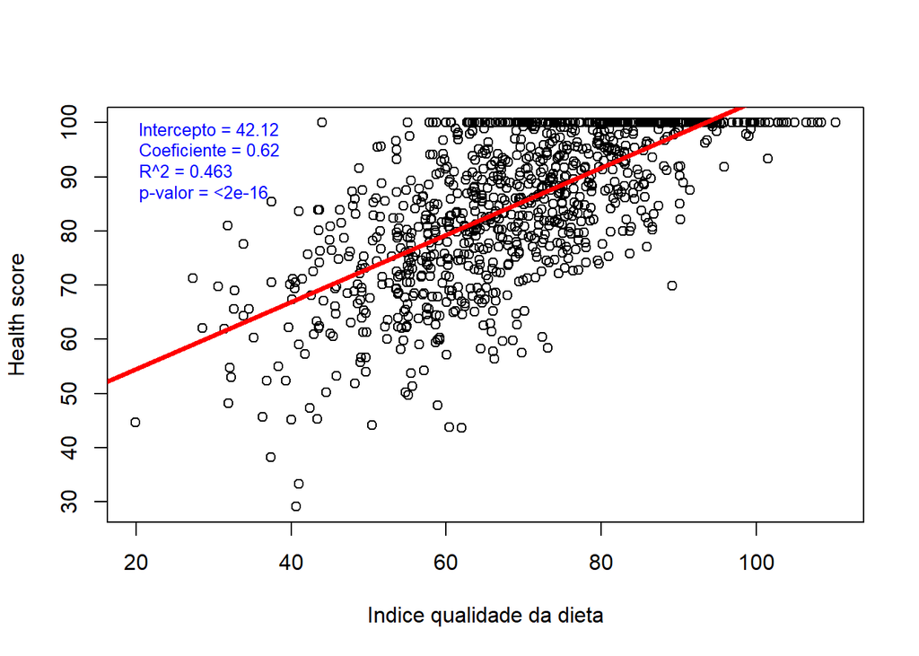

### 8.4.1 Modelo com R2 alto

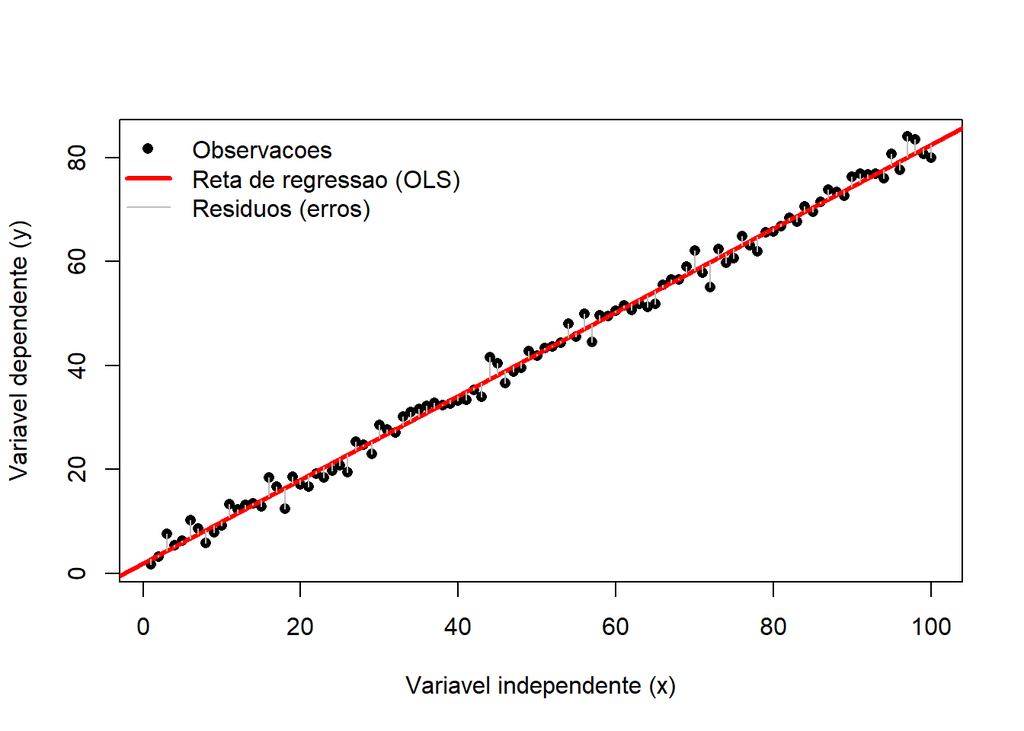

### 8.4.2 Modelo de R2 mais baixo

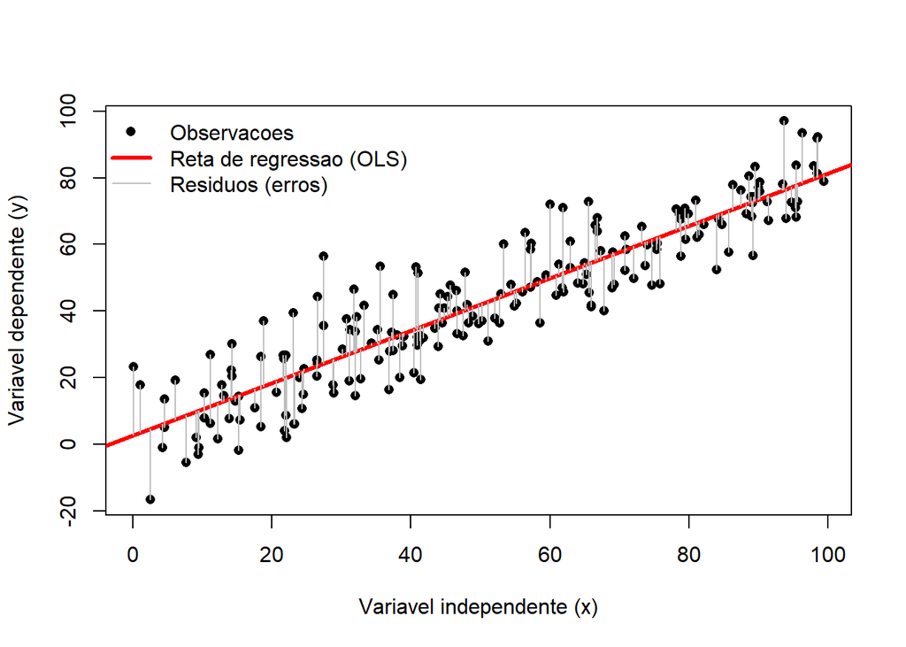

# 9 Anexo: traduções de pacotes utilizados

Cf. Nota dos autores sobre as traduções dos respectivos pacotes [^1]

## 9.1 {NHANES} NHANES

### 9.1.1 Descrição

Estes são dados de pesquisa coletados pelo National Center for Health Statistics (NCHS) dos Estados Unidos, que conduz uma série de levantamentos sobre saúde e nutrição desde o início da década de 1960. Desde 1999, aproximadamente 5.000 indivíduos de todas as idades são entrevistados anualmente em suas casas e realizam exames de saúde em centros móveis de exame (Mobile Examination Centers — MECs). Conjunto de dados em formato data frame, contendo versões brutas e reamostradas dos dados do NHANES. Veja abaixo os detalhes e descrições das variáveis.

### 9.1.2 Detalhes

A população-alvo do NHANES é “a população civil residente não institucionalizada dos Estados Unidos”. O NHANES (Pesquisa Nacional de Saúde e Nutrição dos EUA) utiliza um desenho amostral complexo, que super-representa certas subpopulações, como minorias raciais. Uma análise ingênua dos dados originais do NHANES pode levar a conclusões erradas — por exemplo, as proporções de cada grupo racial nos dados são diferentes das proporções reais da população.

Os conjuntos NHANES e NHANESraw incluem 75 variáveis para os anos de amostragem 2009–2010 e 2011–2012. O NHANESraw contém 20.293 observações dessas variáveis, além de quatro variáveis adicionais que descrevem o esquema de ponderação da amostra. O NHANES contém 10.000 linhas de dados reamostrados de NHANESraw para corrigir os efeitos da superamostragem.

Assim, o NHANES pode ser tratado, para fins educacionais, como se fosse uma amostra aleatória simples da população americana. Uma lista das variáveis e descrições segue abaixo, com links para a documentação original do NHANES.

### 9.1.3 Variáveis do estudo

| Categoria | Variavel | Descricao |
| --- | --- | --- |
| Identificação | SurveyYr | Ano da pesquisa em que o participante foi incluído. |
| Identificação | ID | Identificador único do participante. |
| Variáveis Demográficas | Gender | Sexo do participante (masculino ou feminino). |
| Variáveis Demográficas | Age | Idade em anos no momento da triagem (80 anos ou mais registrados como 80). |
| Variáveis Demográficas | AgeDecade | Categoria etária por décadas (0–9, 10–19, …, 70+). |
| Variáveis Demográficas | AgeMonths | Idade em meses (detalhada para algumas faixas etárias). |
| Variáveis Demográficas | Race1 / Race3 | Raça ou etnia informada (Mexicano, Hispânico, Branco, Negro, Asiático, Outro). |
| Variáveis Demográficas | Education | Nível educacional (Fundamental, Ensino Médio, Faculdade, etc.). |
| Variáveis Demográficas | MaritalStatus | Estado civil (Casado, Viúvo, Divorciado, Solteiro, etc.). |
| Variáveis Demográficas | HHIncome / HHIncomeMid | Faixa e valor médio da renda familiar anual (em dólares). |
| Variáveis Demográficas | Poverty | Razão entre renda familiar e linha de pobreza. |
| Variáveis Demográficas | HomeRooms / HomeOwn | Número de cômodos e tipo de posse da moradia (própria, alugada ou outra). |
| Medidas Físicas | Weight | Peso corporal em quilogramas. |
| Medidas Físicas | Height / Length | Altura em pé ou comprimento deitado em centímetros. |
| Medidas Físicas | HeadCirc | Circunferência da cabeça em centímetros. |
| Medidas Físicas | BMI | Índice de Massa Corporal (IMC). |
| Medidas Físicas | BMICatUnder20yrs / BMI_WHO | Categorias de IMC conforme idade ou classificação da OMS. |
| Medidas Físicas | Pulse / BPSysAve / BPDiaAve | Frequência cardíaca e médias da pressão arterial sistólica e diastólica. |
| Medidas Físicas | BPSys1–3 / BPDia1–3 | Leituras consecutivas da pressão arterial sistólica e diastólica. |
| Medidas Físicas | Testosterone | Nível de testosterona total (ng/dL). |
| Variáveis de Saúde | DirectChol / TotChol | Colesterol HDL direto e colesterol total (mmol/L). |
| Variáveis de Saúde | UrineVol1–2 / UrineFlow1–2 | Volume e fluxo urinário (mL e mL/min). |
| Variáveis de Saúde | Diabetes / DiabetesAge | Diagnóstico de diabetes e idade ao diagnóstico. |
| Variáveis de Saúde | HealthGen | Autoavaliação geral da saúde. |
| Variáveis de Saúde | DaysPhysHlthBad / DaysMentHlthBad | Número de dias com saúde física ou mental ruim nos últimos 30 dias. |
| Variáveis de Saúde | LittleInterest / Depressed | Sintomas de depressão ou falta de interesse. |
| Variáveis de Saúde | nPregnancies / nBabies / PregnantNow / Age1stBaby | Histórico reprodutivo. |
| Variáveis de Saúde | SleepHrsNight / SleepTrouble | Padrões e dificuldades relacionadas ao sono. |
| Variáveis de Estilo de Vida | PhysActive / PhysActiveDays | Prática de atividades físicas e número de dias por semana. |
| Variáveis de Estilo de Vida | TVHrsDay / CompHrsDay | Tempo médio diário assistindo TV ou usando computador/jogos. |
| Variáveis de Estilo de Vida | Alcohol12PlusYr / AlcoholDay / AlcoholYear | Consumo de álcool (frequência e quantidade). |
| Variáveis de Estilo de Vida | Smoke100 / SmokeNow / SmokeAge | Hábito de fumar e idade de início. |
| Variáveis de Estilo de Vida | Marijuana / AgeFirstMarij / RegularMarij / AgeRegMarij | Uso de maconha e idade de início ou uso regular. |
| Variáveis de Estilo de Vida | HardDrugs | Uso de drogas pesadas (cocaína, heroína, etc.). |
| Variáveis de Estilo de Vida | SexEver / SexAge / SexNumPartnLife / SexNumPartYear / SameSex / SexOrientation | Histórico e comportamento sexual. |

## 9.2 {diet} MASS

Dados sobre Dieta e Coração

### 9.2.2 Variáveis do estudo

| Variavel | Tipo | Descricao |
| --- | --- | --- |
| id | Numérico | Identificador do participante. |
| doe | Data | Data de entrada no estudo de acompanhamento. |
| dox | Data | Data de saída do estudo de acompanhamento. |
| dob | Data | Data de nascimento do participante. |
| y | Numérico | Número de anos em risco. |
| fail | Numérico | Status na saída do estudo (códigos 1, 3 e 13 representam eventos de CHD). |
| job | Fator | Ocupação do participante (Driver = motorista, Conductor = cobrador, Bank worker = bancário). |
| month | Numérico | Mês da pesquisa dietética. |
| energy | Numérico | Ingestão total de energia (kCal por dia / 100). |
| height | Numérico | Altura em centímetros. |
| weight | Numérico | Peso em quilogramas. |
| fat | Numérico | Ingestão de gordura (10 g/dia). |
| fibre | Numérico | Ingestão de fibras alimentares (10 g/dia). |
| energy.grp | Fator | Grupo de consumo energético diário (≤2750 KCal ou >2750 KCal). |
| chd | Numérico | Ocorrência de evento coronariano (1 = evento CHD, 0 = sem evento). |

Os dados foram descritos e amplamente utilizados por Clayton e Hills em Statistical Models in Epidemiology (Oxford University Press, Oxford, 1993). Eles foram resgatados da destruição por David Clayton e reintroduzidos a partir de impressões em papel.

## 9.3 {Epi} DMepi

### 9.3.1 Descrição

Contagens e anos-pessoa baseados em registros para a incidência de diabetes e mortalidade com e sem diabetes.

### 9.3.2 Variáveis do estudo

Um data frame com 4.200 observações sobre as seguintes 8 variáveis

| Variavel | Tipo | Descricao |
| --- | --- | --- |
| sex | Fator | Sexo do indivíduo (M = masculino, F = feminino). |
| A | Numérico | Classe etária (0–99 anos). |
| P | Numérico | Ano do calendário (1996–2016). |
| X | Numérico | Número de novos diagnósticos de diabetes entre pessoas sem diabetes. |
| D.nD | Numérico | Número de mortes entre pessoas sem diabetes. |
| Y.nD | Numérico | Anos-pessoa entre pessoas sem diabetes. |
| D.DM | Numérico | Número de mortes entre pessoas com diabetes. |
| Y.DM | Numérico | Anos-pessoa entre pessoas com diabetes. |

Os dados são baseados em registros da população dinamarquesa. Incluídos apenas para fins ilustrativos, não podendo ser usados como dados cientificamente validados, pois números pequenos foram aleatoriamente permutados entre as unidades.

# 10 Anexo: Atividades extras e desafios

**QUESTÃO 1**  
Qual a diferença entre os dois códigos abaixo?

```r
# CÓDIGO 1
4 / 2
```

```r
# CODIGO 2
divisao <- 4 / 2
```

**QUESTÃO 2**  
Escreva um código que guarde em um objeto chamado nome uma string com seu nome completo.

**QUESTÃO 3**  
Escreva um código, seguindo as orientações abaixo. Crie um objeto chamado segredo que vai guardar um número inteiro de 0 a 10. Sem olhar qual número foi guardado no objeto, resolva:

- Verifique se o segredo é maior ou igual a 0;
- Verifique se o segredo é menor ou igual a 10;
- Verifique se o segredo é maior que 5;
- Verifique se o segredo * 5 é maior que a sua idade;
- Qual o valor guardado no objeto segredo?

**QUESTÃO 4**  
Escreva um código seguindo o passo a passo abaixo:

- Crie um objeto que guarde a informação de sua sua idade;
- Multiplique sua idade por 12 e guarde o valor num objeto chamado idade_em_meses;
- Agora multiplique sua idade em meses por 30 para obter sua idade em dias e salve o resultado no objeto idade_em_dias

**QUESTÃO 5**  
Explique por que o código abaixo resulta num erro.

```r
meu - objeto <- 1
```

**QUESTÃO 6**  
Procure na Internet qual é o “número de ouro” e na sequência calcule ele usando o comando function() no R.

```r
# Selecione 5 fórmulas muito utilizadas na graduação, ou na sua vivência profissional, ou que seja afim à sua área de pesquisa e a esboce no R usando de funções como o function(), cat(), os operadores lógicos e matemáticos, e estruturas condicionais.
```

**QUESTÃO 7**  
Por que é preferível escrevermos sempre o nosso código no script e não no Console?

**QUESTÃO 8**  
Marque verdadeiro ou falso para as questões que seguem

[output not shown]

**QUESTÃO 9**  
Use a função rnorm() para gerar dois conjuntos de dados aleatórios com 100 valores e faça um gráfico plotando um dos conjuntos contra o outro. Existem milhares de outros comandos para alterar a aparência de gráficos, veja esta página do help (?par) para ver alguns comandos sobre como alterar a aparência de gráficos. Não se preocupe se você ficar confuso sobre as opções do help(par), apenas praticando você irá começar a dominar estes comandos. Coloque um título no gráfico Use Bolinhas cheias e azuis como símbolo. Coloque as legendas no eixo-x e no eixo-y. O padrão do R é fazer uma “caixa” em torno do gráfico, faça uma alteração para que apareça apenas as linhas do eixo-x e do eixo-y. veja bty em ?par

**QUESTÃO 10**  
Marque verdadeiro ou falso para as questões que seguem

[output not shown]

## 10.1 Desafios

Cf. Nota dos autores sobre os respectivos desafios [^2]

### 10.1.1 Opção 1

[output not shown]

### 10.1.2 Opção 2

[output not shown]

### 10.1.3 Opção 3

[output not shown]

### 10.1.4 Opção 4

[output not shown]

### 10.1.5 Opção 5

[output not shown]

# 11 Referências, notas e materiais de apoio

1. [ANJOS, Adilson dos. Estatística básica com uso do software R. Curitiba: Departamento de Estatística – UFPR, 2010.](https://docs.ufpr.br/~aanjos/TRI/R/rbasico.pdf)
2. [BOLFARINE, Heleno; SANDOVAL, Mônica Carneiro. Introdução à inferência estatística. São Paulo: Blucher, 2018.](https://docs.ufpr.br/~lucambio/CE210/LIVRO%20de%20infer%EAncia%20bolfarine.pdf)
3. CASELLA, George; BERGER, Roger L. Statistical inference. 2nd ed. Belmont, CA: Duxbury Press, 2002.
4. [CHAOUBAH, A. A importância da Bioestatística na formação de um profissional de Saúde. Revista Brasileira de Oftalmologia](https://www.scielo.br/j/rbof/a/ZnvJ63VgxhbhWthX9nVBWgg/?format=html&lang=pt)
5. Correa, S. M. B. B. (2003). Probabilidade e estatística.
6. [Curso: Ciência de Dados em R](https://livro.curso-r.com/index.html)
7. [Figueiredo Filho, Dalson, et al. “O que fazer e o que não fazer com a regressão: pressupostos e aplicações do modelo linear de Mínimos Quadrados Ordinários (MQO).” Revista Política Hoje 20.1 (2011): 44-99.](https://www.academia.edu/8169376/O_que_Fazer_e_o_que_N%C3%A3o_Fazer_com_a_Regress%C3%A3o_pressupostos_e_aplica%C3%A7%C3%B5es_do_modelo_linear_de_M%C3%ADnimos_Quadrados_Ordin%C3%A1rios_MQO)
8. [Grolemund, Garrett. Hands-on programming with R. ” O’Reilly Media, Inc.”, 2014.](https://rstudio-education.github.io/hopr/basics.html)
9. [Hadley Wickham (2010): Uma gramática em camadas de gráficos, Journal of Computational and Graphical Statistics](https://byrneslab.net/classes/biol607/readings/wickham_layered-grammar.pdf)
10. [JAMES, Gareth et al. An Introduction to Statistical Learning: with Applications in R. Second Edition. (S.l.): (s.n.), 2023.](https://www.statlearning.com/)
11. [Kuhn, Max, and Julia Silge. Tidy modeling with R: A framework for modeling in the tidyverse. ” O’Reilly Media, Inc.”, 2022.](https://www.tmwr.org/)
12. [LANDEIRO, Victor Lemes. Introdução ao uso do programa R. Manaus: Instituto Nacional de Pesquisas da Amazônia, Programa de Pós-Graduação em Ecologia](https://cran.r-project.org/doc/contrib/Landeiro-Introducao.pdf)
13. MARTIN, Peter. Linear Regression: an introduction to statistical models. London: SAGE Publications, 2021. 978-1-5264-2417-4. (The SAGE Quantitative Research Kit).
14. [The R Graph Gallery (Site para ver modelos de possíveis gráficos no R)](https://r-graph-gallery.com/index.html)
15. [Wickham H (2014). Dados organizados. Journal of Statistical Software. Volume 59, Edição 10.](https://vita.had.co.nz/papers/tidy-data.pdf)
16. [Wickham, Hadley, Mine Çetinkaya-Rundel, and Garrett Grolemund. R für Data Science: Daten importieren, bereinigen, umformen und visualisieren. O’Reilly, 2024.](https://pt.r4ds.hadley.nz/)
17. Mais informações podem ser encontradas em [tidyverse.org](https://tidyverse.org/)

Mais informações sobre **Regressão Linear** na área de **Nutrição e Saúde** podem sem encontradas abaixo

18. [Costa et tal. Evolução do excesso de peso e fatores associados em mulheres de 10 a 49 anos em Pernambuco, Nordeste, Brasil. Revista de Nutrição](https://www.scielo.br/j/rn/a/4SnTxv5qmCP4kjgPRNBN3QC/?lang=pt)
19. [Pinho et tal. Excesso de peso em adultos do Estado de Pernambuco, Brasil: magnitude e fatores associados. Cadernos de Saúde Pública´](https://www.scielo.br/j/csp/a/yVJSvdS5Xptjh3dHZL4c7GS/?lang=pt)
20. [Silva et tal. Situação de insegurança alimentar em domicílios de Pernambuco, Região Nordeste do Brasil: contribuições para discussão da violação do direito à alimentação. Saúde e Sociedade](https://www.scielo.br/j/sausoc/a/MJNKgg3CTPMLt8DMm3RwjQH/abstract/?lang=pt)

[figure not shown]

[^1]: Traduzido por Ryan Almeida, com o auxílio de Inteligência Artificial, como parte da monitoria do “Curso de Extensão - R para Saúde: Informática Aplicada à Pesquisa Científica” ocorrido entre os dias 3 e 7 de novembro de 2025 no Programa de Pós-Graduação em Nutrição da Universidade Federal de Pernambuco. Uso exclusivo para sala de aula. Reprodução não recomendada.
[^2]: Para ter acesso integral aos dados desses respectivos desafios entre em contato com os autores dessa apostila.